# Metabolic_pathways

Ville Lehtonen

11/3/2020

# Metabolic pathways

Here, we inspect the different metabolic modules / pathways that cells adopt as they progress through the differentiation trajectory. This is done by: - Fetching metabolic module / pathway information from KEGG and creating new sce objects containing only metabolic genes and metabolic module and pathway information on their rowData - Using Scorpius to calculate gene importances and grouping genes into modules using only a subset of metabolic genes - Using singleR to annotate cells using only a subset of metabolic genes - Performing DE analysis using only metabolic genes

The aggregation of gene expression values into modules / pathways, and the subsequent computing of module/pathway importances etc. are separated into another file (Metablic_pathways_pt2.Rmd)

## 1. Load packages and data

### 1.1 Load packages

```r
library(SCORPIUS)
library(scran)
library(scater)
library(SingleCellExperiment)
library(dplyr)
library(SingleR)
library(stats)
library(pheatmap)
library(data.table)
library(KEGGREST)
library(RColorBrewer)
library(gridExtra)
library(gplots)
library(ggplot2)
library(ggpubr)
```

### 1.2 Load pre-calculated data

**Single Cell Experiments**

```r
# Load pre-processed sce objects (used for computing the SCEs containing only metabolic genes)
denoised.sce <- readRDS("./../saved/R_objects/denoised_sce")
denoised.sce.deMicheli <- readRDS("./../saved/R_objects/denoised_sce_deMicheli")
denoised.sce.dellOrso <- readRDS("./../saved/R_objects/denoised_sce_dellOrso")
```

```r
# Load datasets with metabolic genes only
denoised.sce.m <- readRDS("./../saved/R_objects/denoised_sce_m")
denoised.sce.deMicheli.m <- readRDS("./../saved/R_objects/denoised_sce_deMicheli_m")
denoised.sce.dellOrso.m <- readRDS("./../saved/R_objects/denoised_sce_dellOrso_m")

# Filter primary myoblasts from the dellOrso data
primary_mbs.m <- denoised.sce.dellOrso.m$cell_type == "Primary_MB"
denoised.sce.dellOrso.m.f <- denoised.sce.dellOrso.m[, !denoised.sce.dellOrso.m$cell_type == "Primary_MB"]
```

**Trajectories**

```r
# Load pre-calculated trajectory objects
traj.primary <- readRDS("./../saved/R_objects/traj_primary")
traj.deMicheli <- readRDS("./../saved/R_objects/traj_deMicheli")
traj.dellOrso <- readRDS("./../saved/R_objects/traj_dellOrso_f")

# Define group names for trajectories
group_name.primary.m <- as.factor(denoised.sce.m$sample)
group_name.deMicheli.m <- as.factor(denoised.sce.deMicheli.m$cell_type)
group_name.dellOrso.m <- as.factor(denoised.sce.dellOrso.m.f$cell_type)
```

### 1.3 Build trajectories for datasets (Optional)

#### 1.3.1 Primary data

```r
# Create expression and sample objects
expression.primary <- as.matrix(t(logcounts(denoised.sce)))
group_name.primary <- as.factor(denoised.sce$sample)

# Trajectory inference
set.seed(123)
space.primary <- reduce_dimensionality(expression.primary, dist = "spearman", ndim = 2)
set.seed(123)
traj.primary <- infer_trajectory(space.primary)
traj.primary <- reverse_trajectory(traj.primary)
```

#### 1.3.2 De Micheli data

```r
# Create expression and sample objects
expression.deMicheli <- as.matrix(t(logcounts(denoised.sce.deMicheli)))
group_name.deMicheli <- as.factor(denoised.sce.deMicheli$cell_type)

# Trajectory building
set.seed(123)
space.deMicheli <- reduce_dimensionality(expression.deMicheli, dist = "spearman", ndim = 2)
set.seed(123)
traj.deMicheli <- infer_trajectory(space.deMicheli)
traj.deMicheli <- reverse_trajectory(traj.deMicheli)
```

#### 1.3.3 Dell’Orso data

```r
# Create expression and sample objects
expression.dellOrso.f <- as.matrix(t(logcounts(denoised.sce.dellOrso.f)))
group_name.dellOrso.f <- as.factor(denoised.sce.dellOrso.f$cell_type)

# Trajectory building
set.seed(123)
space.dellOrso <- reduce_dimensionality(expression.dellOrso.f, dist = "spearman", ndim = 2)
set.seed(123)
traj.dellOrso <- infer_trajectory(space.dellOrso)
```

## 2. Mapping of KEGG modules & pathways to the datasets

### 2.1 Fetch KEGG modules & pathway information

#### 2.1.2 Fetch KEGG information from pre-computed files

```r
# Fetch KEGG entries information
df.kegg.entries <- readRDS("./../saved/R_objects/df_kegg_entries")
```

#### 2.1.2 Fetch information from KEGG (optional)

**Get all metabolic pathway associated KEGG modules and pathways** The data is available at https://www.genome.jp/dbget-bin/www_bget?pathway:mmu01100

```r
kegg.modules <- read.csv("./../saved/tables/kegg_metabolic_modules.csv", header = FALSE)
colnames(kegg.modules) <- c("module", "module_name")

kegg.pathways <- read.csv("./../saved/tables/kegg_metabolic_pathways.csv", header = FALSE)
colnames(kegg.pathways) <- c("pathway", "pathway_name")
```

**Fetch entry, gene, module, and pathway information from KEGG**

```r
# Fetch all KEGG entries for mouse modules and pathways using the 'module' and 'pathway' databases
mouse.org.id <- "T01002"
mouse.pathways <- keggLink(target = "pathway", source = mouse.org.id)
mouse.modules <- keggLink(target = "module", source = mouse.org.id)

# Filter non-metabolic module/pathway associated KEGG entries
mouse.pathways.f <- mouse.pathways[substring(mouse.pathways, 6) %in% kegg.pathways$pathway]
mouse.modules.f <- mouse.modules[substring(mouse.modules, 4) %in% kegg.modules$module]

# Combine unique KEGG entries for mouse modules / pathways into a single list of entries
mouse.metabolic.entries <- unique(c(names(mouse.modules.f), names(mouse.pathways.f)))

# Build a dataframe to store module, gene, and pathway information for each KEGG entry
df.kegg.entries <- data.frame(entry = mouse.metabolic.entries,
                              module = NA,
                              genes = NA,
                              pathway = NA,
                              module_info = NA,
                              pathway_info = NA)

# For each KEGG entry, fetch the information with keggGet()
for (i in 1:nrow(df.kegg.entries)) {
  print(i)
  entry <- df.kegg.entries[i,]$entry
  query <- keggGet(entry)
  # add gene names
  genes <- query[[1]]$NAME
  # add module IDs
  module.list <- names(query[[1]]$MODULE)
  module.list <- module.list[module.list %in% kegg.modules$module]
  module.id <- paste(module.list, collapse = ", ")
  # add pathway IDs
  pathway.list <- names(query[[1]]$PATHWAY)
  pathway.list <- pathway.list[pathway.list %in% kegg.pathways$pathway]
  pathway.id <- paste(pathway.list, collapse = ", ")
  # Add module information
  module_info.list <- query[[1]]$MODULE
  module_info.list <- module_info.list[names(module_info.list) %in% module.list]
  module_info <- paste(module_info.list, collapse = ", ")
  # Add pathway information
  pathway_info.list <- query[[1]]$PATHWAY
  pathway_info.list <- pathway_info.list[names(pathway_info.list) %in% pathway.list]
  pathway_info <- paste(pathway_info.list, collapse = ", ")
  # Update information to dataframe
  df.kegg.entries[i,]$genes <- genes
  df.kegg.entries[i,]$module <- module.id
  df.kegg.entries[i,]$pathway <- pathway.id
  df.kegg.entries[i,]$module_info <- module_info
  df.kegg.entries[i,]$pathway_info <- pathway_info
}

# Manually correct some of the mispelled gene names in KEGG (ATP6, ATP8, COX1, COX2, COX3, CYTB, ND1, ND2, ND3, ND4, ND4L, ND5, ND6)
# Correct names: mt-Atp6, mt-Atp8, mt-Co1, mt-Co2, mt-Co3, mt-Cytb, mt-Nd1, mt-Nd2, mt-Nd3, mt-Nd4,mt-Nd4l, mt-Nd5, mt-Nd6
df.kegg.entries[df.kegg.entries$genes == "ATP6", ]$genes <- "mt-Atp6"
df.kegg.entries[df.kegg.entries$genes == "ATP8", ]$genes <- "mt-Atp8"
df.kegg.entries[843, ]$genes <- "mt-Co1" # COX1 gene
df.kegg.entries[df.kegg.entries$genes == "COX2", ]$genes <- "mt-Co2"
df.kegg.entries[df.kegg.entries$genes == "COX3", ]$genes <- "mt-Co3"
df.kegg.entries[df.kegg.entries$genes == "CYTB", ]$genes <- "mt-Cytb"
df.kegg.entries[df.kegg.entries$genes == "ND1", ]$genes <- "mt-Nd1"
df.kegg.entries[df.kegg.entries$genes == "ND2", ]$genes <- "mt-Nd2"
df.kegg.entries[df.kegg.entries$genes == "ND3", ]$genes <- "mt-Nd3"
df.kegg.entries[df.kegg.entries$genes == "ND4", ]$genes <- "mt-Nd4"
df.kegg.entries[df.kegg.entries$genes == "ND4L", ]$genes <- "mt-Nd4l"
df.kegg.entries[df.kegg.entries$genes == "ND5", ]$genes <- "mt-Nd5"
df.kegg.entries[df.kegg.entries$genes == "ND6", ]$genes <- "mt-Nd6"

# Save objects
saveRDS(df.kegg.entries, file = "./../saved/R_objects/df_kegg_entries")

# Save as csv
write.csv(df.kegg.entries, file ="./../saved/tables/df_kegg_entries.csv")
```

### 2.2 Add KEGG modules & pathway information to the datasets (Optional)

#### 2.2.1 Primary data

```r
# Load mouse modules if it doesn't exist
if(!exists("df.kegg.entries")) {
  df.kegg.entries <- readRDS("./../saved/R_objects/df_kegg_entries")
}

denoised.sce.m <- denoised.sce
rowData(denoised.sce.m)$module <- ""
rowData(denoised.sce.m)$pathway <- ""
rowData(denoised.sce.m)$module_info <- ""
rowData(denoised.sce.m)$pathway_info <- ""

for(i in 1:nrow(df.kegg.entries)) {
  print(i)
  # Split the gene names into a list
  genes <- unlist(lapply(strsplit(df.kegg.entries[i,]$genes, split = ",")[[1]], trimws))
  # Get the first gene from the list (= the correct gene name)
  gene <- genes[1]
  # If the gene exists in the genes of the sce object, update its row data
  if(gene %in% rownames(denoised.sce)) {
    rowData(denoised.sce.m)[gene, ]$module <- df.kegg.entries[i,]$module
    rowData(denoised.sce.m)[gene, ]$pathway <- df.kegg.entries[i,]$pathway
    rowData(denoised.sce.m)[gene, ]$module_info <- df.kegg.entries[i,]$module_info
    rowData(denoised.sce.m)[gene, ]$pathway_info <- df.kegg.entries[i,]$pathway_info
  }
}

# Subset genes that have associated metabolic module / pathway information
genes.to.use <- rownames(denoised.sce.m)[(rowData(denoised.sce.m)$module != "") | (rowData(denoised.sce.m)$pathway != "")]
denoised.sce.m <- denoised.sce.m[rownames(denoised.sce.m) %in% genes.to.use, ]

# Inspect number of genes
dim(denoised.sce.m)

# Save sce object containing only metabolic genes and module/pathway information stored on rowData
saveRDS(denoised.sce.m, "./../saved/R_objects/denoised_sce_m")
```

#### 2.2.2 De Micheli et al. (2020) reference data

```r
# Load mouse modules if it doesn't exist
if(!exists("df.kegg.entries")) {
  df.kegg.entries <- readRDS("./../saved/R_objects/df_kegg_entries")
}

denoised.sce.deMicheli.m <- denoised.sce.deMicheli
rowData(denoised.sce.deMicheli.m)$module <- ""
rowData(denoised.sce.deMicheli.m)$pathway <- ""
rowData(denoised.sce.deMicheli.m)$module_info <- ""
rowData(denoised.sce.deMicheli.m)$pathway_info <- ""

for(i in 1:nrow(df.kegg.entries)) {
  print(i)
  # Split the gene names into a list
  genes <- unlist(lapply(strsplit(df.kegg.entries[i,]$genes, split = ",")[[1]], trimws))
  # Get the first gene from the list (= the correct gene name)
  gene <- genes[1]
  # If the gene exists in the genes of the sce object, update its row data
  if(gene %in% rownames(denoised.sce.deMicheli.m)) {
    rowData(denoised.sce.deMicheli.m)[gene, ]$module <- df.kegg.entries[i,]$module
    rowData(denoised.sce.deMicheli.m)[gene, ]$pathway <- df.kegg.entries[i,]$pathway
    rowData(denoised.sce.deMicheli.m)[gene, ]$module_info <- df.kegg.entries[i,]$module_info
    rowData(denoised.sce.deMicheli.m)[gene, ]$pathway_info <- df.kegg.entries[i,]$pathway_info
  }
}

genes.to.use <- rownames(denoised.sce.deMicheli.m)[(rowData(denoised.sce.deMicheli.m)$module != "") | (rowData(denoised.sce.deMicheli.m)$pathway != "")]
denoised.sce.deMicheli.m <- denoised.sce.deMicheli.m[rownames(denoised.sce.deMicheli.m) %in% genes.to.use, ]

# Inspect number of genes
dim(denoised.sce.deMicheli.m)

# Save sce object containing only metabolic genes and module/pathway information stored on rowData
saveRDS(denoised.sce.deMicheli.m, "./../saved/R_objects/denoised_sce_deMicheli_m")
```

#### 2.2.3 Dell’Orso et al. (2019) reference data

```r
# Load mouse modules if it doesn't exist
if(!exists("df.kegg.entries")) {
  df.kegg.entries <- readRDS("./../saved/R_objects/df_kegg_entries")
}

denoised.sce.dellOrso.m <- denoised.sce.dellOrso
rowData(denoised.sce.dellOrso.m)$module <- ""
rowData(denoised.sce.dellOrso.m)$pathway <- ""
rowData(denoised.sce.dellOrso.m)$module_info <- ""
rowData(denoised.sce.dellOrso.m)$pathway_info <- ""

for(i in 1:nrow(df.kegg.entries)) {
  print(i)
  # Split the gene names into a list
  genes <- unlist(lapply(strsplit(df.kegg.entries[i,]$genes, split = ",")[[1]], trimws))
  # Get the first gene from the list (= the correct gene name)
  gene <- genes[1]
  # If the gene exists in the genes of the sce object, update its row data
  if(gene %in% rownames(denoised.sce.dellOrso.m)) {
    rowData(denoised.sce.dellOrso.m)[gene, ]$module <- df.kegg.entries[i,]$module
    rowData(denoised.sce.dellOrso.m)[gene, ]$pathway <- df.kegg.entries[i,]$pathway
    rowData(denoised.sce.dellOrso.m)[gene, ]$module_info <- df.kegg.entries[i,]$module_info
    rowData(denoised.sce.dellOrso.m)[gene, ]$pathway_info <- df.kegg.entries[i,]$pathway_info
  }
}

genes.to.use <- rownames(denoised.sce.dellOrso.m)[(rowData(denoised.sce.dellOrso.m)$module != "") | (rowData(denoised.sce.dellOrso.m)$pathway != "")]
denoised.sce.dellOrso.m <- denoised.sce.dellOrso.m[rownames(denoised.sce.dellOrso.m) %in% genes.to.use, ]

# Inspect number of genes
dim(denoised.sce.dellOrso.m)

# Save sce object containing only metabolic genes and module/pathway information stored on rowData
saveRDS(denoised.sce.dellOrso.m, "./../saved/R_objects/denoised_sce_dellOrso_m")
```

## 3. Gene importances using only metabolic genes

### 3.1 Load pre-computed gene importances for all datasets

```r
################
# Primary data
################
# Load gimp & modules
gimp.primary.m <- readRDS("./../saved/R_objects/gimp_primary_m")
modules.primary.m <- readRDS("./../saved/R_objects/modules_primary_m")

gimp.primary.m$qvalue <- p.adjust(p = gimp.primary.m$pvalue, method = "BH")
gene_sel.primary.m <- gimp.primary.m$gene[gimp.primary.m$qvalue < .05]

if(!exists("expression.primary.m")) {expression.primary.m <- as.matrix(t(logcounts(denoised.sce.m)))}
expr_sel.primary.m <- scale_quantile(expression.primary.m[, gene_sel.primary.m])

#############################
# De Micheli data: all cells
#############################
# Load gimp & modules
gimp.deMicheli.m <- readRDS("./../saved/R_objects/gimp_deMicheli_m")
modules.deMicheli.m <- readRDS("./../saved/R_objects/modules_deMicheli_m")

gimp.deMicheli.m$qvalue <- p.adjust(p = gimp.deMicheli.m$pvalue, method = "BH")
gene_sel.deMicheli.m <- gimp.deMicheli.m$gene[gimp.deMicheli.m$qvalue < .05]

if(!exists("expression.deMicheli.m")) {expression.deMicheli.m <- as.matrix(t(logcounts(denoised.sce.deMicheli.m)))}
expr_sel.deMicheli.m <- scale_quantile(expression.deMicheli.m[, gene_sel.deMicheli.m])

#################################################
# De Micheli data: without mature skeletal muscle
#################################################
# Load gimp & modules
gimp.deMicheli.m.f <- readRDS("./../saved/R_objects/gimp_deMicheli_m_no_muscle")
modules.deMicheli.m.f <- readRDS("./../saved/R_objects/modules_deMicheli_m_no_muscle")

gimp.deMicheli.m.f$qvalue <- p.adjust(p = gimp.deMicheli.m.f$pvalue, method = "BH")
gene_sel.deMicheli.m.f <- gimp.deMicheli.m.f$gene[gimp.deMicheli.m.f$qvalue < .05]

if(!exists("expression.deMicheli.m.f")) {
  muscle_cells.m <- denoised.sce.deMicheli.m$cell_type == "d0_mature_skeletal_muscle" | denoised.sce.deMicheli.m$cell_type =="d5_mature_skeletal_muscle" | denoised.sce.deMicheli.m$cell_type == "d7_mature_skeletal_muscle"
  denoised.sce.deMicheli.m.f <- denoised.sce.deMicheli.m[, !muscle_cells.m]
  expression.deMicheli.m.f <- as.matrix(t(logcounts(denoised.sce.deMicheli.m.f)))
  }
expr_sel.deMicheli.m.f <- scale_quantile(expression.deMicheli.m.f[, gene_sel.deMicheli.m.f])
group_name.deMicheli.m.f <- as.factor(denoised.sce.deMicheli.m.f$cell_type)
traj.deMicheli.f.time <- traj.deMicheli$time[names(traj.deMicheli$time) %in% colnames(denoised.sce.deMicheli.m.f)]

###########################################
# Dell'Orso data: without primary myoblasts
###########################################
# Read gimp & modules from a file
gimp.dellOrso.m.f <- readRDS("./../saved/R_objects/gimp_dellOrso_m_no_primaryMB")
modules.dellOrso.m.f <- readRDS("./../saved/R_objects/modules_dellOrso_m_no_primaryMB")

# Create expression and sample objects
gimp.dellOrso.m.f$qvalue <- p.adjust(p = gimp.dellOrso.m.f$pvalue, method = "BH")
gene_sel.dellOrso.m.f <- gimp.dellOrso.m.f$gene[gimp.dellOrso.m.f$qvalue < .05]

if(!exists("expression.dellOrso.m.f")) {expression.dellOrso.m.f <- as.matrix(t(logcounts(denoised.sce.dellOrso.m.f)))}
expr_sel.dellOrso.m.f <- scale_quantile(expression.dellOrso.m.f[, gene_sel.dellOrso.m.f])
group_name.dellOrso.m.f <- as.factor(denoised.sce.dellOrso.m.f$cell_type)
```

**Save gimp / module information into csv files**

```r
# Primary data
write.csv(gimp.primary.m[gimp.primary.m$gene %in% gene_sel.primary.m, ], file = "./../saved/tables/gimp_primary_m.csv")
write.csv(modules.primary.m, file = "./../saved/tables/modules_primary_m.csv")

# De Micheli data: all cells
write.csv(gimp.deMicheli.m[gimp.deMicheli.m$gene %in% gene_sel.deMicheli.m, ], file = "./../saved/tables/gimp_deMicheli_m.csv")
write.csv(modules.deMicheli.m, file = "./../saved/tables/modules_deMicheli_m.csv")

# De Micheli data: without mature skeletal muscle
write.csv(gimp.deMicheli.m.f[gimp.deMicheli.m.f$gene %in% gene_sel.deMicheli.m.f, ], file = "./../saved/tables/gimp_deMicheli_m_f.csv")
write.csv(modules.deMicheli.m.f, file = "./../saved/tables/modules_deMicheli_m_f.csv")

# Dell'Orso data: without primary myoblasts
write.csv(gimp.dellOrso.m.f[gimp.dellOrso.m.f$gene %in% gene_sel.dellOrso.m.f, ], file = "./../saved/tables/gimp_dellOrso_m_f.csv")
write.csv(modules.dellOrso.m.f, file = "./../saved/tables/modules_dellOrso_m_f.csv")
```

### 3.2 Primary data

### 3.2.1 Compute gene importances

```r
# Read trajectory from a file (if not defined)
if(!exists("traj.primary")) {
  traj.primary <- readRDS("./../saved/R_objects/traj_primary")
}

# Create expression and sample objects
expression.primary.m <- as.matrix(t(logcounts(denoised.sce.m)))
group_name.primary.m <- as.factor(denoised.sce.m$sample)

# Gene importances
gimp.primary.m <- gene_importances(x = expression.primary.m,
                                           time = traj.primary$time,
                                           num_permutations = 10,
                                           num_threads = 8)

gimp.primary.m$qvalue <- p.adjust(p = gimp.primary.m$pvalue, method = "BH")
gene_sel.primary.m <- gimp.primary.m$gene[gimp.primary.m$qvalue < .05]
expr_sel.primary.m <- scale_quantile(expression.primary.m[, gene_sel.primary.m])

#saveRDS(gimp.primary.m, file = "./../saved/R_objects/gimp_primary_m")

# Extract modules
modules.primary.m <- extract_modules(expr_sel.primary.m,
                                     time = traj.primary$time,
                                     verbose = FALSE)
#saveRDS(modules.primary.m, "./../saved/R_objects/modules_primary_m")
```

### 3.2.3 Visualize gene importances

**Make a trajectory heatmap**

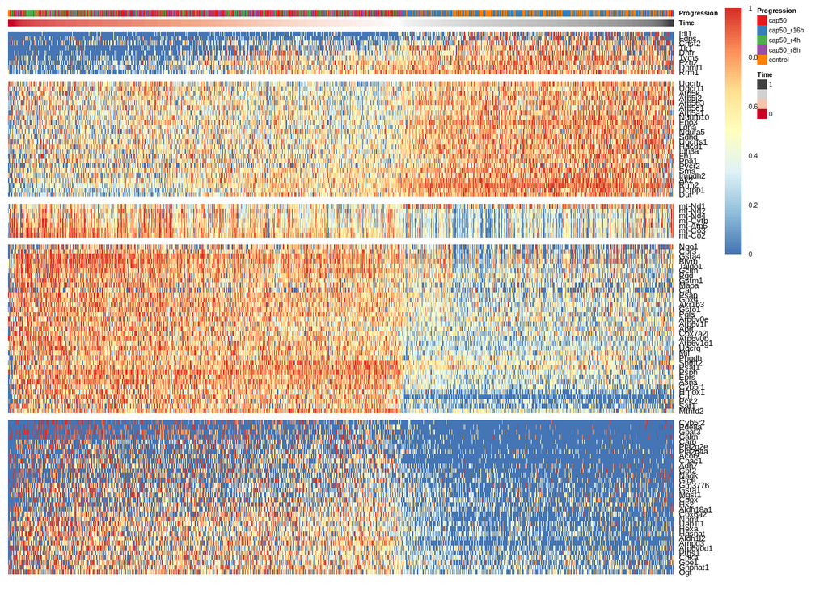

```r
draw_trajectory_heatmap(expr_sel.primary.m,
                        time = traj.primary$time,
                        progression_group = group_name.primary.m,
                        modules = modules.primary.m,
                        show_labels_row = TRUE,
                        fontsize_row = 5,
                        fontsize = 4)
```

**Save as pdf**

```r
# Gimp
pdf("./../saved/figures/gimp_heatmap_primary_metabolic_genes.pdf")
draw_trajectory_heatmap(expr_sel.primary.m,
                        time = traj.primary$time,
                        progression_group = group_name.primary.m,
                        show_labels_row = TRUE,
                        fontsize_row = 5)
dev.off()

# Modules
pdf("./../saved/figures/modules_heatmap_primary_metabolic_genes.pdf")
draw_trajectory_heatmap(expr_sel.primary.m,
                        time = traj.primary$time,
                        progression_group = group_name.primary.m,
                        modules = modules.primary.m,
                        show_labels_row = TRUE,
                        fontsize_row = 5,
                        fontsize = 4)
dev.off()
```

### 3.3 De Micheli data

#### 3.3.1 Gimp: All cell types

##### 3.3.1.1 Compute gene importances

```r
# Read trajectory from a file (if not defined)
if(!exists("traj.deMicheli")) {
  traj.deMicheli <- readRDS("./../saved/R_objects/traj_deMicheli")
}

# Create expression and sample objects
expression.deMicheli.m <- as.matrix(t(logcounts(denoised.sce.deMicheli.m)))
group_name.deMicheli.m <- as.factor(denoised.sce.deMicheli.m$cell_type)

# Gene importances
gimp.deMicheli.m <- gene_importances(x = expression.deMicheli.m,
                                     time = traj.deMicheli$time,
                                     num_permutations = 10,
                                     num_threads = 8)

gimp.deMicheli.m$qvalue <- p.adjust(p = gimp.deMicheli.m$pvalue, method = "BH")
gene_sel.deMicheli.m <- gimp.deMicheli.m$gene[gimp.deMicheli.m$qvalue < .05]
expr_sel.deMicheli.m <- scale_quantile(expression.deMicheli.m[, gene_sel.deMicheli.m])

#saveRDS(gimp.deMicheli.m, file = "./../saved/R_objects/gimp_deMicheli_m")

# Extract modules
modules.deMicheli.m <- extract_modules(expr_sel.deMicheli.m,
                                       time = traj.deMicheli$time,
                                       verbose = FALSE)

#saveRDS(modules.deMicheli.m, "./../saved/R_objects/modules_deMicheli_m")
```

##### 3.3.1.2 Visualize gene importances

**Make a trajectory heatmap**

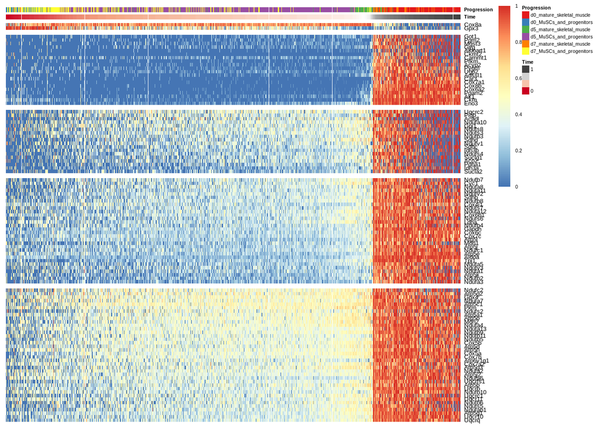

```r
draw_trajectory_heatmap(expr_sel.deMicheli.m,
                        time = traj.deMicheli$time,
                        progression_group = group_name.deMicheli.m,
                        modules = modules.deMicheli.m,
                        show_labels_row = TRUE,
                        fontsize_row = 5,
                        fontsize = 4)
```

**Save as pdf**

```r
# Gimp
pdf("./../saved/figures/gimp_heatmap_deMicheli_metabolic_genes.pdf")
draw_trajectory_heatmap(expr_sel.deMicheli.m,
                        time = traj.deMicheli$time,
                        progression_group = group_name.deMicheli.m,
                        show_labels_row = TRUE,
                        fontsize_row = 5,
                        fontsize = 4)
dev.off()

# Modules
pdf("./../saved/figures/modules_heatmap_deMicheli_metabolic_genes.pdf")
draw_trajectory_heatmap(expr_sel.deMicheli.m,
                        time = traj.deMicheli$time,
                        progression_group = group_name.deMicheli.m,
                        modules = modules.deMicheli.m,
                        show_labels_row = TRUE,
                        fontsize_row = 5,
                        fontsize = 4)
dev.off()
```

#### 3.3.2 Gimp: Without mature skeletal muscle

##### 3.3.2.1 Compute gene importances

```r
muscle_cells <- denoised.sce.deMicheli$cell_type == "d0_mature_skeletal_muscle" | denoised.sce.deMicheli$cell_type =="d5_mature_skeletal_muscle" | denoised.sce.deMicheli$cell_type == "d7_mature_skeletal_muscle"
denoised.sce.deMicheli.f <- denoised.sce.deMicheli[, !muscle_cells]

muscle_cells.m <- denoised.sce.deMicheli.m$cell_type == "d0_mature_skeletal_muscle" | denoised.sce.deMicheli.m$cell_type =="d5_mature_skeletal_muscle" | denoised.sce.deMicheli.m$cell_type == "d7_mature_skeletal_muscle"
denoised.sce.deMicheli.m.f <- denoised.sce.deMicheli.m[, !muscle_cells.m]

# Define expression of metabolic genes
expression.deMicheli.m <- as.matrix(t(logcounts(denoised.sce.deMicheli.m.f)))

# Calculate trajectory with all genes but without skeletal muscle
expression.deMicheli <- as.matrix(t(logcounts(denoised.sce.deMicheli.f)))
set.seed(123)
space.deMicheli <- reduce_dimensionality(expression.deMicheli, dist = "spearman", ndim = 2)
set.seed(123)
traj.deMicheli <- infer_trajectory(space.deMicheli)
traj.deMicheli <- reverse_trajectory(traj.deMicheli)

# Gimp
gimp.deMicheli.m <- gene_importances(x = expression.deMicheli.m,
                                     time = traj.deMicheli$time,
                                     num_permutations = 10,
                                     num_threads = 8)

saveRDS(gimp.deMicheli.m, file = "./../saved/R_objects/gimp_deMicheli_m_no_muscle")

gimp.deMicheli.m$qvalue <- p.adjust(p = gimp.deMicheli.m$pvalue, method = "BH")
gene_sel.deMicheli.m <- gimp.deMicheli.m$gene[gimp.deMicheli.m$qvalue < .05]
expr_sel.deMicheli.m <- scale_quantile(expression.deMicheli.m[, gene_sel.deMicheli.m])

# Modules
modules.deMicheli.m <- extract_modules(expr_sel.deMicheli.m,
                                       time = traj.deMicheli$time,
                                       verbose = FALSE)

saveRDS(modules.deMicheli.m, file = "./../saved/R_objects/modules_deMicheli_m_no_muscle")
```

##### 3.3.2.2 Visualize gene importances

**Make a trajectory heatmap**

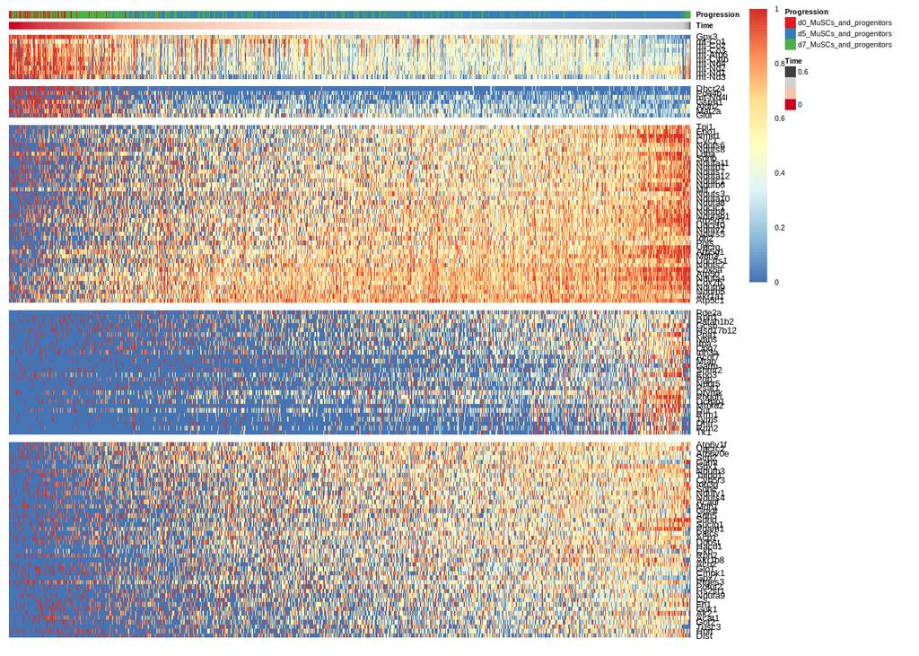

```r
draw_trajectory_heatmap(expr_sel.deMicheli.m.f,
                        time = traj.deMicheli.f.time,
                        progression_group = group_name.deMicheli.m.f,
                        modules = modules.deMicheli.m.f,
                        show_labels_row = TRUE,
                        fontsize_row = 5,
                        fontsize = 4)
```

**Save as pdf**

```r
# Gimp
pdf("./../saved/figures/gimp_heatmap_deMicheli_metabolic_genes_no_muscle.pdf")
draw_trajectory_heatmap(expr_sel.deMicheli.m.f,
                        time = traj.deMicheli.f.time,
                        progression_group = group_name.deMicheli.m.f,
                        show_labels_row = TRUE,
                        fontsize_row = 5,
                        fontsize = 4)
dev.off()

# Modules
pdf("./../saved/figures/modules_heatmap_deMicheli_metabolic_genes_no_muscle.pdf")
draw_trajectory_heatmap(expr_sel.deMicheli.m.f,
                        time = traj.deMicheli.f.time,
                        progression_group = group_name.deMicheli.m.f,
                        modules = modules.deMicheli.m.f,
                        show_labels_row = TRUE,
                        fontsize_row = 5,
                        fontsize = 4)
dev.off()
```

### 3.4 Dell’Orso data

#### 3.4.1 Gimp: Without primary myoblasts

##### 3.4.1.1 Compute gene importances (optional)

```r
# Subset PMs from both datasets
primary_mbs <- denoised.sce.dellOrso$cell_type == "Primary_MB"
denoised.sce.dellOrso.f <- denoised.sce.dellOrso[, !primary_mbs]

primary_mbs.m <- denoised.sce.dellOrso.m$cell_type == "Primary_MB"
denoised.sce.dellOrso.m.f <- denoised.sce.dellOrso.m[, !primary_mbs.m]

# Define expression of metabolic genes
expression.dellOrso.m <- as.matrix(t(logcounts(denoised.sce.dellOrso.m.f)))

# Calculate trajectory with all genes but without skeletal muscle
expression.dellOrso <- as.matrix(t(logcounts(denoised.sce.dellOrso.f)))
set.seed(123)
space.dellOrso <- reduce_dimensionality(expression.dellOrso, dist = "spearman", ndim = 2)
set.seed(123)
traj.dellOrso <- infer_trajectory(space.dellOrso)

# Gimp
gimp.dellOrso.m <- gene_importances(x = expression.dellOrso.m,
                                     time = traj.dellOrso$time,
                                     num_permutations = 10,
                                     num_threads = 8)

saveRDS(gimp.dellOrso.m, file = "./../saved/R_objects/gimp_dellOrso_m_no_primaryMB")

gimp.dellOrso.m$qvalue <- p.adjust(p = gimp.dellOrso.m$pvalue, method = "BH")
gene_sel.dellOrso.m <- gimp.dellOrso.m$gene[gimp.dellOrso.m$qvalue < .05]
expr_sel.dellOrso.m <- scale_quantile(expression.dellOrso.m[, gene_sel.dellOrso.m])

# Modules
modules.dellOrso.m <- extract_modules(expr_sel.dellOrso.m,
                                       time = traj.dellOrso$time,
                                       verbose = FALSE)

saveRDS(modules.dellOrso.m, file = "./../saved/R_objects/modules_dellOrso_m_no_primaryMB")
```

##### 3.4.1.2 Visualize gene importances

**Make a trajectory heatmap**

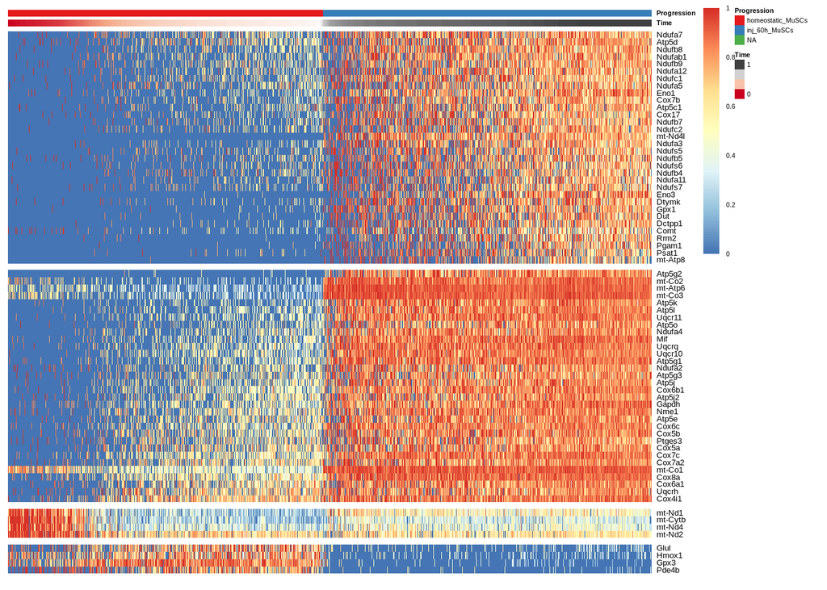

```r
draw_trajectory_heatmap(expr_sel.dellOrso.m.f,
                        time = traj.dellOrso$time,
                        progression_group = group_name.dellOrso.m.f,
                        modules = modules.dellOrso.m.f,
                        show_labels_row = TRUE,
                        fontsize_row = 5,
                        fontsize = 4)
```

**save as pdf**

```r
# Gimp
pdf("./../saved/figures/gimp_heatmap_dellOrso_metabolic_genes_no_PM.pdf")
draw_trajectory_heatmap(expr_sel.dellOrso.m.f,
                        time = traj.dellOrso$time,
                        progression_group = group_name.dellOrso.m.f,
                        show_labels_row = TRUE,
                        fontsize_row = 5,
                        fontsize = 4)
dev.off()

# Modules
pdf("./../saved/figures/modules_heatmap_dellOrso_metabolic_genes_no_PM.pdf")
draw_trajectory_heatmap(expr_sel.dellOrso.m.f,
                        time = traj.dellOrso$time,
                        progression_group = group_name.dellOrso.m.f,
                        modules = modules.dellOrso.m.f,
                        show_labels_row = TRUE,
                        fontsize_row = 5,
                        fontsize = 4)
dev.off()
```

### 3.5 Comparison of metabolic genes between the datasets

```r
# Load metabolic genes if not defined
if(!exists("modules.primary.m")) {modules.primary.m <- readRDS("./../saved/R_objects/modules_primary_m")}
if(!exists("modules.deMicheli.m")) {modules.deMicheli.m <- readRDS("./../saved/R_objects/modules_deMicheli_m")}
if(!exists("modules.deMicheli.m.f")) {modules.deMicheli.m.f <- readRDS("./../saved/R_objects/modules_deMicheli_m_no_muscle")}
if(!exists("modules.dellOrso.m.f")) {modules.dellOrso.m.f <- readRDS("./../saved/R_objects/modules_dellOrso_m_no_primaryMB")}


v.table <- venn(data = list(primary_data = modules.primary.m$feature,
                            de_Micheli_data = modules.deMicheli.m$feature,
                            dellOrso_data = modules.dellOrso.m.f$feature))
```

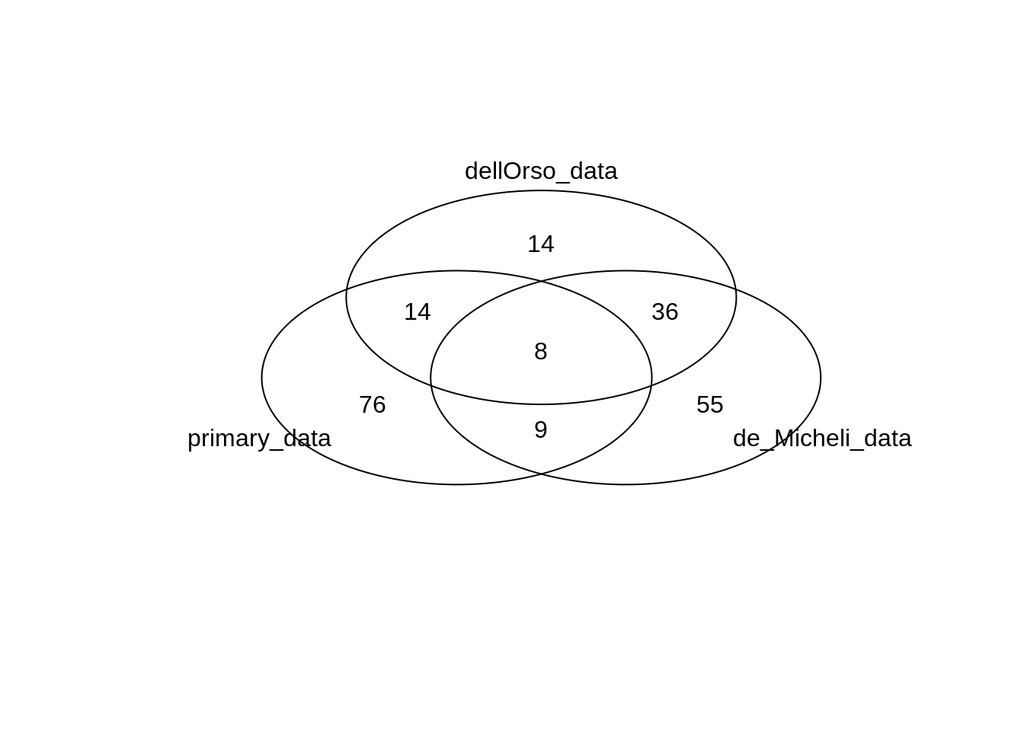

```r
# Print the intersections between datasets
print(attr(v.table ,"intersections"))
```

```
## $primary_data
##  [1] "Idi1"     "Fdps"     "Chst2"    "Tk1"      "Dhfr"     "Tyms"
##  [7] "Ezh2"     "Dnmt1"    "Rrm1"     "Hacd1"    "Fh1"      "Ppa1"
## [13] "Pycr2"    "Sms"      "Impdh2"   "Ak2"      "Nqo1"     "Cbr3"
## [19] "Gsta4"    "Blvrb"    "Taldo1"   "Gclm"     "Pgd"      "Gstm1"
## [25] "Maoa"     "Cat"      "Psap"     "Akr1b3"   "Gsto1"    "Pgls"
## [31] "Atp6v0e"  "Atp6v1f"  "Aprt"     "Cox7a2l"  "Atp6v0b"  "Phgdh"
## [37] "Shmt2"    "Psph"     "Eprs"     "Asns"     "Cyb5r1"   "Cth"
## [43] "Pck2"     "Sat1"     "Mthfd2"   "Cyb5r2"   "Pde8a"    "Gpat3"
## [49] "Galm"     "Car6"     "Pla2g2e"  "Pla2g4a"  "Acot2"    "Chac1"
## [55] "Adh7"     "Gpt2"     "Nagk"     "Glce"     "Gm3776"   "Gsta1"
## [61] "Mgst1"    "Cpox"     "Hk2"      "Aldh18a1" "Nnmt"     "Uap1l1"
## [67] "Hexa"     "Hgsnat"   "Aldh1l2"  "Ampd3"    "Atp6v0d1" "Ptgs1"
## [73] "Chka"     "Gbe1"     "Gnpnat1"  "Ogt"
##
```

[output cut: 34 more lines]

```r
v.table.f <- venn(data = list(primary_data = modules.primary.m$feature,
                              de_Micheli_data = modules.deMicheli.m.f$feature,
                              dellOrso_data = modules.dellOrso.m.f$feature))
```

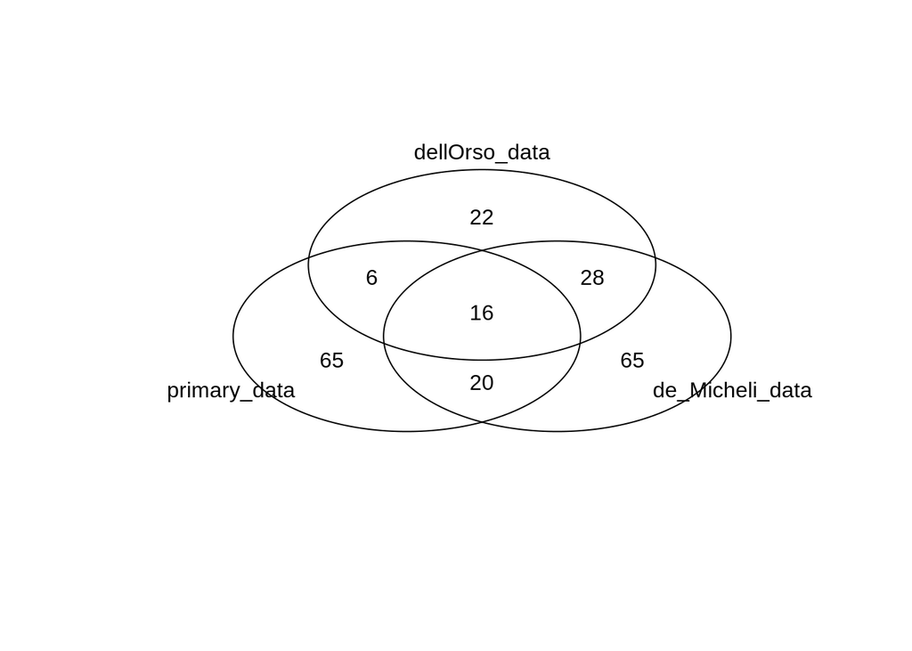

```r
# Print the intersections between datasets
print(attr(v.table.f ,"intersections"))
```

```
## $primary_data
##  [1] "Idi1"     "Fdps"     "Chst2"    "Ezh2"     "Dnmt1"    "Atp5a1"
##  [7] "Ndufb10"  "Pycr2"    "Sms"      "Impdh2"   "Nqo1"     "Cbr3"
## [13] "Gsta4"    "Blvrb"    "Gclm"     "Pgd"      "Maoa"     "Cat"
## [19] "Psap"     "Gpx4"     "Akr1b3"   "Gsto1"    "Aprt"     "Cox7a2l"
## [25] "Atp6v0b"  "Atp6v1g1" "Psph"     "Eprs"     "Asns"     "Cyb5r1"
## [31] "Cth"      "Pck2"     "Sat1"     "Cyb5r2"   "Pde8a"    "Gpat3"
## [37] "Galm"     "Car6"     "Pla2g2e"  "Pla2g4a"  "Acot2"    "Chac1"
## [43] "Adh7"     "Gpt2"     "Nagk"     "Glce"     "Gm3776"   "Gsta1"
## [49] "Mgst1"    "Cpox"     "Hk2"      "Aldh18a1" "Cox6a2"   "Nnmt"
## [55] "Uap1l1"   "Hexa"     "Hgsnat"   "Aldh1l2"  "Ampd3"    "Atp6v0d1"
## [61] "Ptgs1"    "Chka"     "Gbe1"     "Gnpnat1"  "Ogt"
##
## $dellOrso_data
##  [1] "Ndufa7"  "Atp5d"   "Cox17"   "Ndufc2"  "Ndufa3"  "Ndufb4"  "Comt"
```

[output cut: 35 more lines]

```r
# Shared genes between both Venn diagrams
all.shared.m.genes <- c(attr(v.table.f ,"intersections")$`primary_data:de_Micheli_data:dellOrso_data`,
                        attr(v.table ,"intersections")$`primary_data:de_Micheli_data:dellOrso_data`) %>% unique()

print(all.shared.m.genes %>% toString())
```

```
## [1] "Atp5g3, Atp5c1, Eno3, Rrm2, Dctpp1, Dut, mt-Nd1, mt-Nd2, mt-Nd4, mt-Cytb, mt-Atp6, mt-Co3, mt-Co2, Uqcrq, Mif, Psat1, Uqcr11, Atp5k, Atp5j2, Ndufa5"
```

```r
# Genes shared with at least two trajectories
every.shared.gene <- c(attr(v.table.f ,"intersections")$`primary_data:de_Micheli_data:dellOrso_data`,
                       attr(v.table.f ,"intersections")$`primary_data:de_Micheli_data`,
                       attr(v.table.f ,"intersections")$`primary_data:dellOrso_data`,
                       attr(v.table.f ,"intersections")$`de_Micheli_data:dellOrso_data`,
                       attr(v.table ,"intersections")$`primary_data:de_Micheli_data:dellOrso_data`,
                       attr(v.table ,"intersections")$`primary_data:de_Micheli_data`,
                       attr(v.table ,"intersections")$`primary_data:dellOrso_data`,
                       attr(v.table ,"intersections")$`de_Micheli_data:dellOrso_data`) %>% unique()

print(length(every.shared.gene))
```

```
## [1] 93
```

```r
print(every.shared.gene %>% toString())
```

```
## [1] "Atp5g3, Atp5c1, Eno3, Rrm2, Dctpp1, Dut, mt-Nd1, mt-Nd2, mt-Nd4, mt-Cytb, mt-Atp6, mt-Co3, mt-Co2, Uqcrq, Mif, Psat1, Tk1, Dhfr, Tyms, Rrm1, Ldha, Sdhd, Uqcrfs1, Hacd1, Idh3a, Fh1, Ppa1, Ak2, Taldo1, Gstm1, Pgls, Atp6v0e, Atp6v1f, Phgdh, Shmt2, Mthfd2, Uqcrh, Uqcr11, Atp5k, Atp5j2, Ndufa5, H…
```

```r
# Save Venn diagrams as R objects
#saveRDS(v.table, file = "./../saved/R_objects/venn_metabolic_genes")
#saveRDS(v.table.f, file = "./../saved/R_objects/venn_metabolic_genes_f")
```

### 3.6 DE analysis of the shared metabolic genes with high importance in predicting the ordering of cells on trajectories

**T-test**

```r
# Get list of important genes from the Venn diagram
important.m.genes <- c(attr(v.table ,"intersections")$`primary_data:de_Micheli_data:dellOrso_data`,
                       attr(v.table ,"intersections")$`primary_data:de_Micheli_data`,
                       attr(v.table ,"intersections")$`primary_data:dellOrso_data`)

important.m.genes.f <- c(attr(v.table.f ,"intersections")$`primary_data:de_Micheli_data:dellOrso_data`,
                       attr(v.table.f ,"intersections")$`primary_data:de_Micheli_data`,
                       attr(v.table.f ,"intersections")$`primary_data:dellOrso_data`)

all.important.genes <- c(important.m.genes, important.m.genes.f)

# Compute gene importances
markers.primary.gimp <- findMarkers(denoised.sce.m,
                                    groups = denoised.sce.m$sample,
                                    lfc = log2(1.5))

# Choose markers for control sample
control.markers.gimp <- markers.primary.gimp[["control"]]
control.markers.gimp <- control.markers.gimp[rownames(control.markers.gimp) %in% all.important.genes, ]

# Inspect most upregulated and downregulated genes
control.markers.gimp.up <- control.markers.gimp[control.markers.gimp$summary.AUC >= 0.7, ]
control.markers.gimp.down <- control.markers.gimp[control.markers.gimp$summary.AUC <= 0.3, ]

print(control.markers.gimp.up %>% rownames() %>% toString())
print(control.markers.gimp.down %>% rownames() %>% toString())

# Extract the marker effect sizes
logFCs <- getMarkerEffects(control.markers.gimp)

pheatmap(logFCs, breaks=seq(-5, 5, length.out=101), main = "DE analysis: Important metabolic marker genes (t-test): Control vs. other samples", fontsize_row = 12)
```

**WMW test**

```r
# Get list of important genes from the Venn diagram
important.m.genes <- c(attr(v.table ,"intersections")$`primary_data:de_Micheli_data:dellOrso_data`,
                       attr(v.table ,"intersections")$`primary_data:de_Micheli_data`,
                       attr(v.table ,"intersections")$`primary_data:dellOrso_data`)

important.m.genes.f <- c(attr(v.table.f ,"intersections")$`primary_data:de_Micheli_data:dellOrso_data`,
                       attr(v.table.f ,"intersections")$`primary_data:de_Micheli_data`,
                       attr(v.table.f ,"intersections")$`primary_data:dellOrso_data`)

all.important.genes <- c(important.m.genes, important.m.genes.f)

# Compute gene importances
markers.primary.gimp <- findMarkers(denoised.sce.m,
                                    groups = denoised.sce.m$sample,
                                    lfc = log2(1.5),
                                    test = "wilcox")

# Choose markers for control sample
control.markers.gimp <- markers.primary.gimp[["control"]]
control.markers.gimp <- control.markers.gimp[rownames(control.markers.gimp) %in% all.important.genes, ]

# Flip the direction of up / down regulation
control.markers.gimp <- data.frame(as.data.frame(control.markers.gimp)[1:3], apply(control.markers.gimp[4:8], 2, function(x) {abs(1-x)}))

# Save marker information to .csv file
write.csv(control.markers.gimp, file = "./../saved/tables/control_marker_gimp.csv")

# Apply FDR threshold
de.genes.gimp <- control.markers.gimp[(control.markers.gimp$FDR <= 0.1), ]

de.genes.gimp.up <- de.genes.gimp[de.genes.gimp$summary.AUC >= 0.7, ]
de.genes.gimp.down <- de.genes.gimp[de.genes.gimp$summary.AUC <= 0.3, ]

print(de.genes.gimp.up %>% rownames() %>% toString())
```

```
## [1] "Taldo1, mt-Nd2, mt-Co2, Gstm1, mt-Nd1, Gpx4, Cox6a2, Hmox1, Uqcrq, mt-Co3, Atp6v1g1, mt-Cytb, Mthfd2, Pgls, Shmt2, Atp6v1f, mt-Nd4, mt-Atp6, Phgdh"
```

```r
print(de.genes.gimp.down %>% rownames() %>% toString())
```

```
## [1] "Rrm2, Eno3, Tyms, Rrm1, Dut, Tk1, Dctpp1, Ak2, Fh1, Hacd1"
```

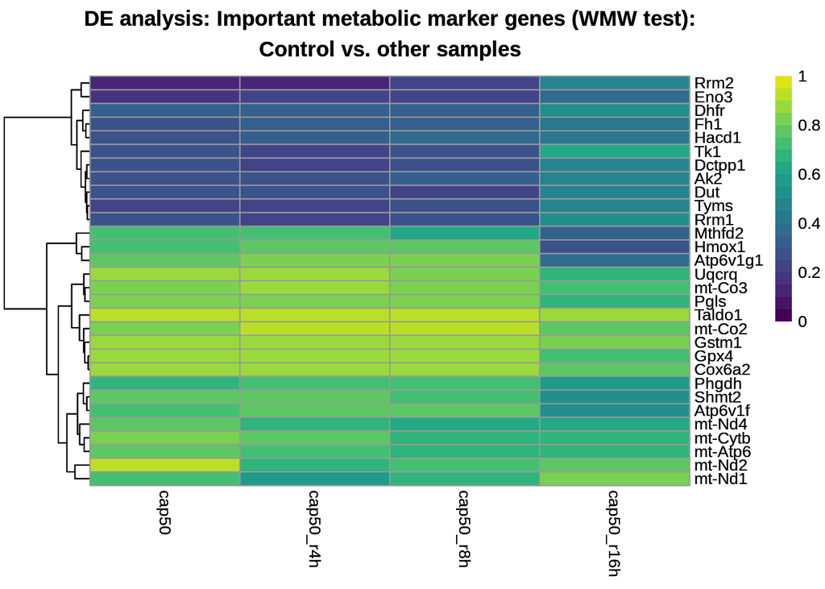

```r
# Extract the area under curves
AUCs <- getMarkerEffects(de.genes.gimp, prefix="AUC")
AUCs <- AUCs[, c("cap50", "cap50_r4h", "cap50_r8h", "cap50_r16h")]

# Plot results in a heatmap
de.important.m.genes <- pheatmap(AUCs, breaks=seq(0, 1, length.out=21), color=viridis::viridis(21), main = "DE analysis: Important metabolic marker genes (WMW test):\nControl vs. other samples", cluster_cols = FALSE)

de.important.m.genes
```

```r
# Save as R object
#saveRDS(de.important.m.genes, file = "./../saved/R_objects/plot_de_important_m_genes")
```

## 4. SingleR cell annotations using only metabolic genes

### 4.1 Cell annotation: all cell types

#### 4.1.1 Load pre-computed prediction objects

```r
# Load prediction objects
pred.deMicheli.m <- readRDS("./../saved/R_objects/pred_deMicheli_m")

# Print the de genes used
de.genes.pred.deMicheli.m <- metadata(pred.deMicheli.m)$common.genes
print(de.genes.pred.deMicheli.m)
```

```
##   [1] "Gpx3"       "Cox8a"      "Gstm1"      "Glul"       "Pde4b"
##   [6] "mt-Nd5"     "Cox6a1"     "Akr1b3"     "Mat2a"      "Aldh2"
##  [11] "mt-Nd4l"    "Akr1a1"     "Eno1"       "Psap"       "Sat1"
##  [16] "Dad1"       "mt-Nd3"     "mt-Co2"     "mt-Atp6"    "mt-Co1"
##  [21] "mt-Nd2"     "mt-Cytb"    "mt-Co3"     "mt-Nd4"     "Ckm"
##  [26] "mt-Nd1"     "Aldoa"      "Uqcr11"     "Ndufa6"     "Ldha"
##  [31] "Atp5k"      "Uqcrb"      "Atp5e"      "Atp5l"      "Atp6v1g1"
##  [36] "Ndufb4"     "Uqcr10"     "Ndufa2"     "Ndufb10"    "Ndufa7"
##  [41] "Ndufc2"     "Gpx4"       "Atp5a1"     "Pkm"        "Eno3"
##  [46] "Car3"       "Cox6a2"     "Pgam2"      "Cox8b"      "Cox5a"
##  [51] "Tpi1"       "Cox7a1"     "Cox7b"      "Ak1"        "Atp5o"
##  [56] "Ndufc1"     "Ndufb8"     "Ndufa5"     "Ndufa3"     "Ndufa12"
##  [61] "Ndufv2"     "Uqcrfs1"    "Pygm"       "Ndufs7"     "Sdhb"
##  [66] "Ugp2"       "Adssl1"     "Gapdh"      "Ndufb2"     "Atp5g1"
##  [71] "Ndufv3"     "Ndufs5"     "Ndufs6"     "Mdh1"       "Cyc1"
```

[output cut: 44 more lines]

#### 4.1.2 Predict cell types (optional)

```r
# De Micheli
pred.deMicheli.m <- SingleR(test = denoised.sce.m,
                                   assay.type.test = "logcounts",
                                   ref = denoised.sce.deMicheli.m,
                                   labels = denoised.sce.deMicheli.m$cell_type)

saveRDS(pred.deMicheli.m, file = "./../saved/R_objects/pred_deMicheli_m")
```

#### 4.1.3 Inspect predictions

```r
# De Micheli
tab.deMicheli.m <- t(table(pred.deMicheli.m$pruned.labels, denoised.sce.m$sample)[, c("control", "cap50", "cap50_r4h","cap50_r8h","cap50_r16h")])
tab.deMicheli.m
```

```
##
##              d5_mature_skeletal_muscle d5_MuSCs_and_progenitors
##   control                         1002                     2731
##   cap50                            326                     4513
##   cap50_r4h                        303                     3486
##   cap50_r8h                        285                     3951
##   cap50_r16h                       501                     4443
```

```r
# Perform chi-seq test
chisq.deMicheli.m <- chisq.test(tab.deMicheli.m)

# Print some statistics
chisq.deMicheli.m$p.value
```

```
## [1] 3.083199e-246
```

```r
chisq.deMicheli.m$expected
```

```
##
##              d5_mature_skeletal_muscle d5_MuSCs_and_progenitors
##   control                     418.8599                 3314.140
##   cap50                       542.9582                 4296.042
##   cap50_r4h                   425.1434                 3363.857
##   cap50_r8h                   475.2988                 3760.701
##   cap50_r16h                  554.7397                 4389.260
```

```r
chisq.deMicheli.m$residuals
```

```
##
##              d5_mature_skeletal_muscle d5_MuSCs_and_progenitors
##   control                   28.4930225              -10.1294876
##   cap50                     -9.3109266                3.3101057
##   cap50_r4h                 -5.9238240                2.1059648
##   cap50_r8h                 -8.7287637                3.1031423
##   cap50_r16h                -2.2816586                0.8111471
```

**balloon plots**

```r
df.deMicheli.m <- melt(t(tab.deMicheli.m))
```

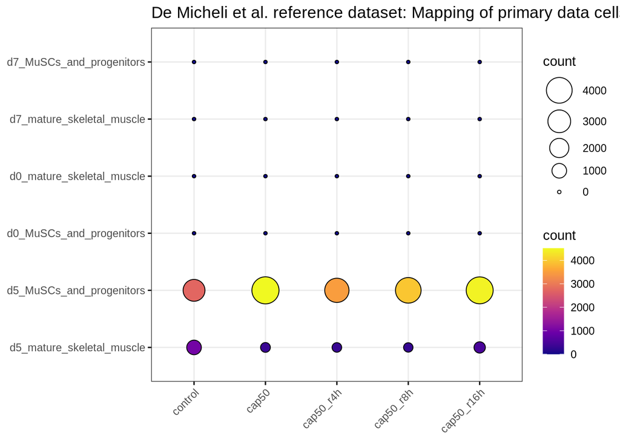

```r
colnames(df.deMicheli.m) <- c("cell_type", "sample", "count")

df.deMicheli.m.missing.rows <- data.frame("cell_type" = c(rep("d0_MuSCs_and_progenitors", 5),
                                                        rep("d0_mature_skeletal_muscle", 5),
                                                        rep("d7_mature_skeletal_muscle", 5),
                                                        rep("d7_MuSCs_and_progenitors", 5)),
                                        "sample" = rep(c("control", "cap50", "cap50_r4h", "cap50_r8h", "cap50_r16h"), 4),
                                        "count" = rep(0, 20))

df.deMicheli.m <- rbind(df.deMicheli.m, df.deMicheli.m.missing.rows)

balloon.deMicheli.m <- ggballoonplot(df.deMicheli.m, x = "sample", y = "cell_type", size = "count",
                                   fill = "count", ggtheme = theme_bw()) +
  scale_fill_viridis_c(option = "C") +
  ggtitle("De Micheli et al. reference dataset: Mapping of primary data cells")


balloon.deMicheli.m
```

```r
# Save as R object
saveRDS(balloon.deMicheli.m, file = "./../saved/R_objects/plot_balloon_deMicheli_m")
```

**DE analysis between the control cells mapping to mature muscle**

```r
# Assign de Micheli cell types to primary data and inspect sample vs. prediction
denoised.sce.m.control <- denoised.sce.m
denoised.sce.m.control$cell_type_deMicheli_m <- pred.deMicheli.m$pruned.labels
denoised.sce.m.control <- denoised.sce.m.control[, denoised.sce.m.control$sample == "control"]

# Inspect the amount of cells belonging to the cell types
table(denoised.sce.m.control$sample, denoised.sce.m.control$cell_type_deMicheli_m)

# Perform DE analysis
markers.control.wmw <- findMarkers(denoised.sce.m.control,
                                   groups = denoised.sce.m.control$cell_type_deMicheli_m,
                                   lfc = log2(1.5),
                                   test="wilcox")

# Choose markers for the muscle sample
muscle.markers.wmw <- markers.control.wmw[["d5_mature_skeletal_muscle"]]

# Flip the direction of up / down regulation
muscle.markers.wmw <- data.frame(as.data.frame(muscle.markers.wmw)[1:3], apply(muscle.markers.wmw[4:5], 2, function(x) {abs(1-x)}))

# apply thresholds
muscle.markers.wmw <- muscle.markers.wmw[(muscle.markers.wmw$FDR <= 0.1) & (muscle.markers.wmw$summary.AUC >= 0.7 |muscle.markers.wmw$summary.AUC <= 0.3), ]

muscle.markers.wmw
```

#### 4.1.4 Diagnostic plots

**De Micheli**

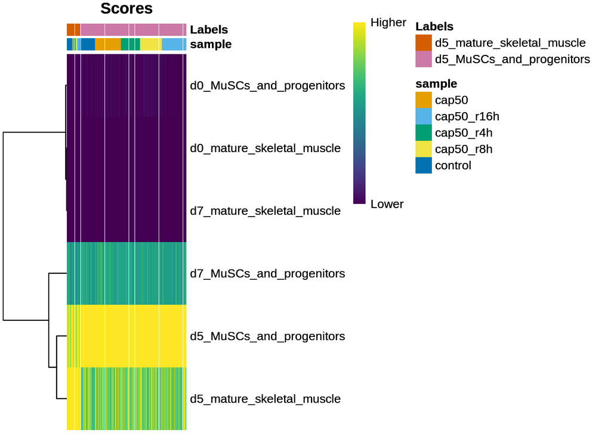

```r
# Score heatmap
plotScoreHeatmap(pred.deMicheli.m, annotation_col = as.data.frame(colData(denoised.sce.m)[, "sample", drop = FALSE]), width = 10)
```

```r
# Remove low-quality cells
to.remove <- pruneScores(pred.deMicheli.m, min.diff.next = 0.1)
table(Label=pred.deMicheli.m$labels, Removed=to.remove)
```

```
##                            Removed
## Label                        TRUE
##   d5_mature_skeletal_muscle  2450
##   d5_MuSCs_and_progenitors  19358
```

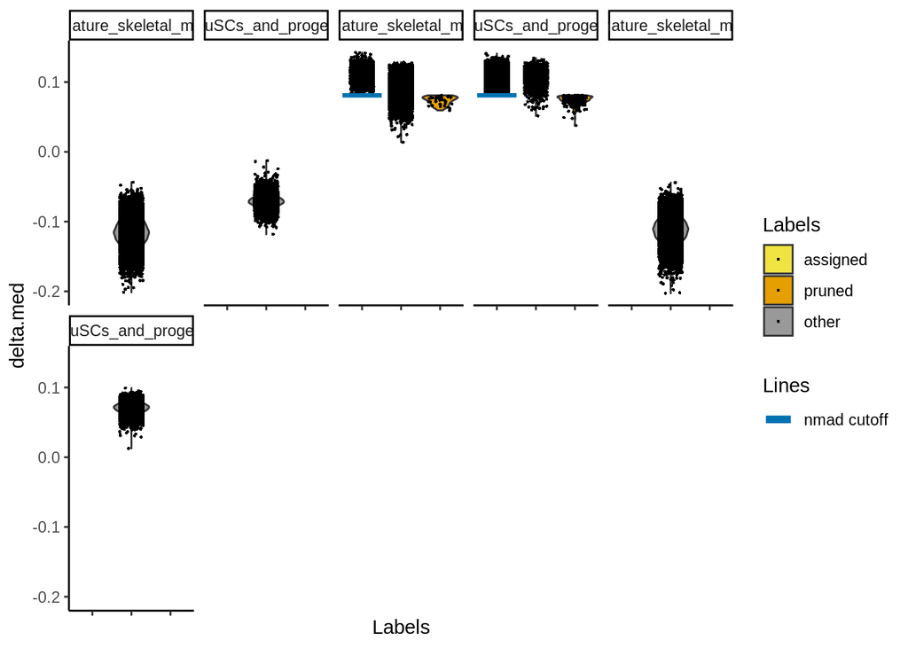

```r
# Delta distribution
plotScoreDistribution(results = pred.deMicheli.m, show = "delta.med")
```

```r
# Markers
all.markers.deMicheli <- metadata(pred.deMicheli.m)$de.genes
denoised.sce.m$cell_type_deMicheli.m <- pred.deMicheli.m$labels

# Delta for only control cells
# pred.deMicheli.m.control <- pred.deMicheli.m[rownames(pred.deMicheli.m) %in% colnames(denoised.sce.m.control), ]
#
# # Assign delta
# pred.deMicheli.m.control <- na.omit(pred.deMicheli.m.control)
# pred.deMicheli.m.control$delta <- getDeltaFromMedian(pred.deMicheli.m.control)
```

**Pdf heatmaps**

```r
#########################
# De Micheli predcitions
#########################
pdf("./../saved/figures/cell_annotation_heatmap_deMicheli_metabolic_genes_d0muscle.pdf")
plotHeatmap(denoised.sce.m,
            order_columns_by="cell_type_deMicheli.m",
            features=unique(unlist(all.markers.deMicheli$d0_mature_skeletal_muscle)),
            fontsize_row = 5)
dev.off()

pdf("./../saved/figures/cell_annotation_heatmap_deMicheli_metabolic_genes_d0musc.pdf")
plotHeatmap(denoised.sce.m,
            order_columns_by="cell_type_deMicheli.m",
            features=unique(unlist(all.markers.deMicheli$d0_MuSCs_and_progenitors)),
            fontsize_row = 5)
dev.off()


pdf("./../saved/figures/cell_annotation_heatmap_deMicheli_metabolic_genes_d5muscle.pdf")
plotHeatmap(denoised.sce.m,
            order_columns_by="cell_type_deMicheli.m",
            features=unique(unlist(all.markers.deMicheli$d5_mature_skeletal_muscle)),
            fontsize_row = 5)
dev.off()


pdf("./../saved/figures/cell_annotation_heatmap_deMicheli_metabolic_genes_d5musc.pdf")
plotHeatmap(denoised.sce.m,
            order_columns_by="cell_type_deMicheli.m",
            features=unique(unlist(all.markers.deMicheli$d5_MuSCs_and_progenitors)),
            fontsize_row = 5)
dev.off()


pdf("./../saved/figures/cell_annotation_heatmap_deMicheli_metabolic_genes_d7muscle.pdf")
plotHeatmap(denoised.sce.m,
            order_columns_by="cell_type_deMicheli.m",
            features=unique(unlist(all.markers.deMicheli$d7_mature_skeletal_muscle)),
            fontsize_row = 5)
dev.off()


pdf("./../saved/figures/cell_annotation_heatmap_deMicheli_metabolic_genes_d7musc.pdf")
plotHeatmap(denoised.sce.m,
            order_columns_by="cell_type_deMicheli.m",
            features=unique(unlist(all.markers.deMicheli$d7_MuSCs_and_progenitors)),
            fontsize_row = 5)
dev.off()
```

### 4.2 Cell annotation: Without mature skeletal muscle and primary myoblasts

#### 4.2.1 Load pre-computed prediction objects

```r
# Load prediction objects
pred.deMicheli.m.no.muscle <- readRDS("./../saved/R_objects/pred_deMicheli_m_no_muscle")
pred.dellOrso.m.no.pm <- readRDS("./../saved/R_objects/pred_dellOrso_m_no_pm")

# Print the de genes used
de.genes.pred.deMicheli.m.no.muscle <- metadata(pred.deMicheli.m.no.muscle)$common.genes
print(de.genes.pred.deMicheli.m.no.muscle)
```

```
##   [1] "Gpx3"     "Pde4b"    "Ckm"      "Gstm1"    "mt-Nd4l"  "mt-Nd3"
##   [7] "mt-Nd1"   "Aldh2"    "Glul"     "Mat2a"    "mt-Nd4"   "mt-Nd2"
##  [13] "mt-Cytb"  "mt-Co3"   "Sat1"     "mt-Atp6"  "mt-Co2"   "Aldoa"
##  [19] "mt-Nd5"   "Uqcr11"   "Ndufa6"   "Eno1"     "mt-Co1"   "Ldha"
##  [25] "Atp5k"    "Uqcrb"    "Atp5e"    "Cox6a1"   "Atp5l"    "Atp6v1g1"
##  [31] "Ndufb4"   "Uqcr10"   "Ndufa2"   "Ndufb10"  "Ndufa7"   "Ndufc2"
##  [37] "Gpx4"     "Psap"     "Atp5a1"   "Pkm"      "Cox5a"    "Atp5o"
##  [43] "Cox7b"    "Mif"      "Ndufs2"   "Atp5g3"   "Uqcrfs1"  "Nme1"
##  [49] "Idh2"     "Gpx1"     "Ndufb8"   "Ndufs5"   "Ndufv2"   "Pgls"
##  [55] "Impdh2"   "Ndufb6"   "Ndufa12"  "Sdhb"     "Cyc1"     "Ndufs3"
##  [61] "Gpi1"     "Uqcrc2"   "Ndufa8"   "Ndufa10"  "Ndufb7"   "Ndufs7"
##  [67] "Tpi1"     "Ndufc1"   "Atp6v1f"  "Cyb5r3"   "Aprt"     "Odc1"
##  [73] "Atp6v0e"  "Gamt"     "Pgam1"    "Ndufa11"  "Ndufs6"   "Ndufs8"
##  [79] "Ckb"      "Prdx6"    "Pigp"     "Sirt2"    "Scp2"     "Ndufb3"
##  [85] "Comt"     "Ndufv1"   "Akr1b8"   "Sdhd"     "Taldo1"   "Idh3g"
```

[output cut: 24 more lines]

```r
de.genes.pred.dellOrso.m.no.pm <- metadata(pred.dellOrso.m.no.pm)$common.genes
print(de.genes.pred.dellOrso.m.no.pm)
```

```
##   [1] "Gpx3"     "Hmox1"    "Mat2a"    "Txnrd1"   "Glul"     "Pde4b"
##   [7] "Eprs"     "Gclm"     "Odc1"     "mt-Nd2"   "mt-Atp6"  "mt-Co3"
##  [13] "mt-Co2"   "Mif"      "Uqcr11"   "Uqcrq"    "Atp5g1"   "Atp5l"
##  [19] "Cox6c"    "Gapdh"    "Uqcr10"   "Atp5k"    "Cox6b1"   "Nme1"
##  [25] "Ndufa4"   "Cox7a2"   "Cox5b"    "Atp5e"    "Atp5j"    "Atp5g2"
##  [31] "Atp5j2"   "Cox5a"    "Ptges3"   "Ndufa2"   "mt-Nd4l"  "Atp5o"
##  [37] "Atp5g3"   "Eno1"     "Pkm"      "Ndufb8"   "Ndufa7"   "Uqcrb"
##  [43] "Atp5d"    "Ndufb9"   "Ndufab1"  "Ndufa12"  "Cox7b"    "Ndufc1"
##  [49] "mt-Co1"   "Cox17"    "Atp5h"    "Ndufa3"   "Gpx4"     "Ldha"
##  [55] "Mdh2"     "Atp5c1"   "Ndufa5"   "Eno3"     "Ndufc2"   "Ndufb7"
##  [61] "Atp5a1"   "Cyc1"     "Ndufa13"  "Cox7c"    "mt-Nd3"   "Dut"
##  [67] "Gpx1"     "Ndufs5"   "Dtymk"    "Ndufb5"   "Rrm2"     "Dctpp1"
##  [73] "Comt"     "Ndufs7"   "Ndufb10"  "Ndufs6"   "Sdhb"     "Cox7a2l"
##  [79] "Ndufa6"   "Ndufb6"   "Ndufb11"  "Uqcrfs1"  "Ndufb4"   "Atp6v1g1"
##  [85] "Ndufa11"  "Ndufb2"   "Cox8a"    "Pgam1"    "Psat1"    "Aprt"
##  [91] "Uqcrc1"   "Mthfd2"   "Hacd1"    "Srm"      "Prdx6"    "Ndufa1"
##  [97] "Cox6a1"   "Atp6v0e"  "Dad1"     "St3gal5"  "Akr1a1"   "mt-Atp8"
## [103] "Sdhd"     "Ndufs8"   "Sms"      "Ndufb3"   "Ak2"      "Phgdh"
## [109] "Gstp1"    "Ndufa8"   "Uqcrh"    "Cox4i1"   "Aldoa"    "mt-Nd1"
## [115] "Atp5b"    "mt-Nd5"   "mt-Cytb"  "mt-Nd4"
```

```r
# Filter muscle / pm cells
muscle_cells <- denoised.sce.deMicheli.m$cell_type == "d0_mature_skeletal_muscle" | denoised.sce.deMicheli.m$cell_type =="d5_mature_skeletal_muscle" | denoised.sce.deMicheli.m$cell_type == "d7_mature_skeletal_muscle"
denoised.sce.deMicheli.m.no.muscle <- denoised.sce.deMicheli.m[, !muscle_cells]
```

#### 4.2.2 Predict cell types (optional)

```r
# Filter out primary MBs and mature skeletal muscle
muscle_cells <- denoised.sce.deMicheli.m$cell_type == "d0_mature_skeletal_muscle" | denoised.sce.deMicheli.m$cell_type =="d5_mature_skeletal_muscle" | denoised.sce.deMicheli.m$cell_type == "d7_mature_skeletal_muscle"
denoised.sce.deMicheli.m.no.muscle <- denoised.sce.deMicheli.m[, !muscle_cells]


# De Micheli
pred.deMicheli.m <- SingleR(test = denoised.sce.m,
                            assay.type.test = "logcounts",
                            ref = denoised.sce.deMicheli.m.no.muscle,
                            labels = denoised.sce.deMicheli.m.no.muscle$cell_type)

saveRDS(pred.deMicheli.m.no.muscle, file = "pred_deMicheli_m_no_muscle")

## Dell'Orso
pred.dellOrso.m <- SingleR(test = denoised.sce.m,
                           assay.type.test = "logcounts",
                           ref = denoised.sce.dellOrso.m.f,
                           labels = denoised.sce.dellOrso.m.f$cell_type)

saveRDS(pred.dellOrso.m.no.pm, file = "./../saved/R_objects/pred_dellOrso_m_no_pm")
```

#### 4.2.3 Inspect predictions

```r
# De Micheli (no mature skeletal muscle)
tab.deMicheli.m <- t(table(pred.deMicheli.m.no.muscle$pruned.labels, denoised.sce.m$sample)[, c("control", "cap50", "cap50_r4h","cap50_r8h","cap50_r16h")])
tab.deMicheli.m
```

```
##
##              d5_MuSCs_and_progenitors d7_MuSCs_and_progenitors
##   control                        3735                        5
##   cap50                          4959                       13
##   cap50_r4h                      3805                        3
##   cap50_r8h                      4259                        0
##   cap50_r16h                     4951                        0
```

```r
# Dell'Orso (no primary myoblasts)
tab.dellOrso.m <- t(table(pred.dellOrso.m.no.pm$pruned.labels, denoised.sce.m$sample)[, c("control", "cap50", "cap50_r4h","cap50_r8h","cap50_r16h")])
tab.dellOrso.m
```

```
##
##              homeostatic_MuSCs inj_60h_MuSCs
##   control                    0          3753
##   cap50                      0          5022
##   cap50_r4h                  0          3815
##   cap50_r8h                  1          4261
##   cap50_r16h                 0          4955
```

#### 4.2.4 Diagnostic plots

**De Micheli**

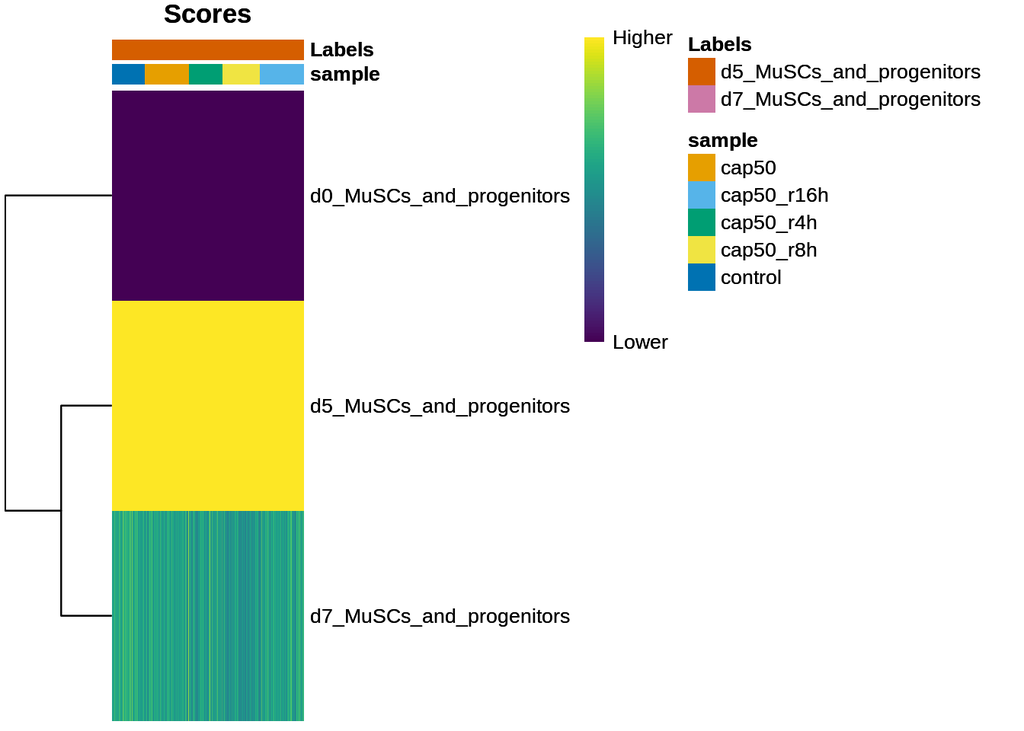

```r
# Score heatmap
plotScoreHeatmap(pred.deMicheli.m.no.muscle, annotation_col = as.data.frame(colData(denoised.sce.m)[, "sample", drop = FALSE]), width = 10)
```

```r
# Remove low-quality cells
to.remove <- pruneScores(pred.deMicheli.m.no.muscle, min.diff.next = 0.1)
table(Label=pred.deMicheli.m.no.muscle$labels, Removed=to.remove)
```

```
##                           Removed
## Label                       TRUE
##   d5_MuSCs_and_progenitors 21787
##   d7_MuSCs_and_progenitors    21
```

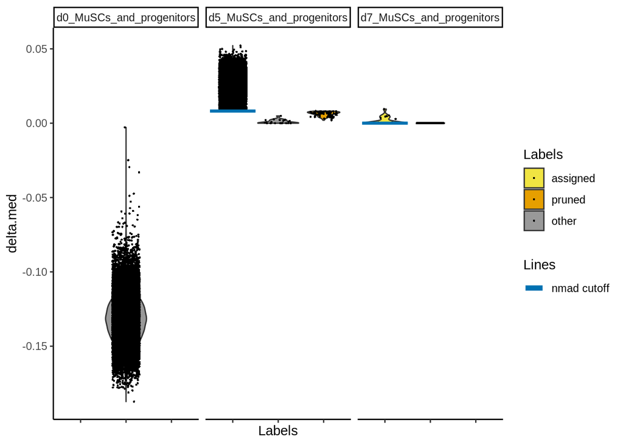

```r
# Delta distribution
plotScoreDistribution(results = pred.deMicheli.m.no.muscle, show = "delta.med")
```

```r
# Markers
all.markers.deMicheli <- metadata(pred.deMicheli.m.no.muscle)$de.genes
denoised.sce.m$cell_type_deMicheli.m.f <- pred.deMicheli.m.no.muscle$labels
```

**Dell’Orso**

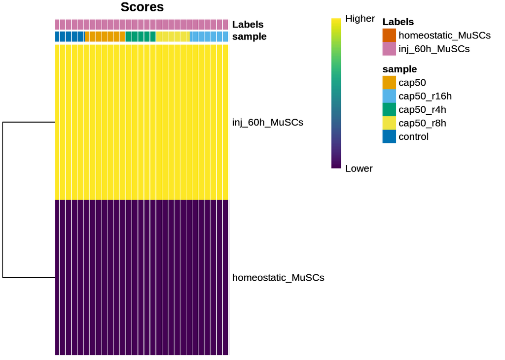

```r
# Score heatmap
plotScoreHeatmap(pred.dellOrso.m.no.pm, annotation_col = as.data.frame(colData(denoised.sce.m)[, "sample", drop = FALSE]), width = 10)
```

```r
# Remove low-quality cells
to.remove <- pruneScores(pred.dellOrso.m.no.pm, min.diff.next = 0.1)
table(Label=pred.dellOrso.m.no.pm$labels, Removed=to.remove)
```

```
##                    Removed
## Label               FALSE  TRUE
##   homeostatic_MuSCs     0     1
##   inj_60h_MuSCs     21736    71
```

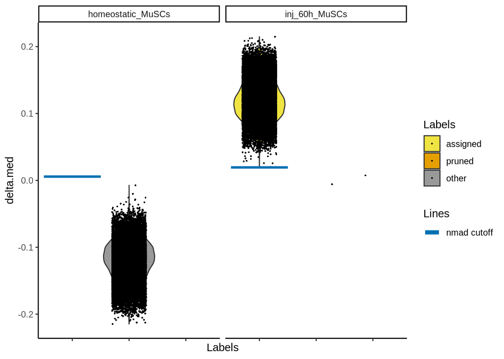

```r
# Delta distribution
plotScoreDistribution(results = pred.dellOrso.m.no.pm, show = "delta.med")
```

```r
# Markers
all.markers.dellOrso <- metadata(pred.dellOrso.m.no.pm)$de.genes
denoised.sce.m$cell_type_dellOrso.m.f <- pred.dellOrso.m.no.pm$labels
```

**Pdf heatmaps**

```r
#########################
# De Micheli predcitions
#########################
pdf("./../saved/figures/cell_annotation_heatmap_deMicheli_filtered_metabolic_genes_d0musc.pdf")
plotHeatmap(denoised.sce.m,
            order_columns_by="cell_type_deMicheli.m.f",
            features=unique(unlist(all.markers.deMicheli$d0_MuSCs_and_progenitors)),
            fontsize_row = 5)
dev.off()


pdf("./../saved/figures/cell_annotation_heatmap_deMicheli_filtered_metabolic_genes_d5musc.pdf")
plotHeatmap(denoised.sce.m,
            order_columns_by="cell_type_deMicheli.m.f",
            features=unique(unlist(all.markers.deMicheli$d5_MuSCs_and_progenitors)),
            fontsize_row = 5)
dev.off()


pdf("./../saved/figures/cell_annotation_heatmap_deMicheli_filtered_metabolic_genes_d7musc.pdf")
plotHeatmap(denoised.sce.m,
            order_columns_by="cell_type_deMicheli.m.f",
            features=unique(unlist(all.markers.deMicheli$d7_MuSCs_and_progenitors)),
            fontsize_row = 5)
dev.off()

#######################
# Dell'Orso predcitions
#######################
pdf("./../saved/figures/cell_annotation_heatmap_dellOrso_filtered_metabolic_genes_hom.pdf")
plotHeatmap(denoised.sce.m,
            order_columns_by="cell_type_dellOrso.m.f",
            features=unique(unlist(all.markers.dellOrso$homeostatic_MuSCs)),
            fontsize_row = 5)
dev.off()

pdf("./../saved/figures/cell_annotation_heatmap_dellOrso_filtered_metabolic_genes_inj60.pdf")
plotHeatmap(denoised.sce.m,
            order_columns_by="cell_type_dellOrso.m.f",
            features=unique(unlist(all.markers.dellOrso$inj_60h_MuSCs)),
            fontsize_row = 5)
dev.off()
```

### 4.3 Cell annotation: using only important genes

#### 4.3.1 Load predictions

```r
# Load prediction objects
pred.deMicheli.important.genes <- readRDS("./../saved/R_objects/pred_deMicheli_important_genes")
pred.dellOrso.important.genes <- readRDS("./../saved/R_objects/pred_dellOrso_important_genes_f")

# Print the de genes used
de.genes.pred.deMicheli.important.genes <- metadata(pred.deMicheli.important.genes)$common.genes
print(de.genes.pred.deMicheli.important.genes)
```

```
##   [1] "Eno3"     "Car3"     "Cox6a2"   "Pgam2"    "Ckm"      "Cox8b"
##   [7] "Cox5a"    "Tpi1"     "Cox7a1"   "Cox7b"    "Aldoa"    "Ak1"
##  [13] "Atp5o"    "Ndufc1"   "Ndufb8"   "Ndufa5"   "Ndufa3"   "Ndufa12"
##  [19] "Ndufv2"   "Uqcrfs1"  "Pygm"     "Ndufs7"   "Sdhb"     "Ugp2"
##  [25] "Adssl1"   "Gapdh"    "Ndufb2"   "Atp5g1"   "Ndufv3"   "Ndufs5"
##  [31] "Ndufs6"   "Mdh1"     "Cyc1"     "Ndufa11"  "Atp5g3"   "Pfkm"
##  [37] "Acyp2"    "Ndufa8"   "Uqcrq"    "Ndufa4"   "Ndufs3"   "Atp5k"
##  [43] "Ndufs2"   "Ndufb7"   "Ndufa1"   "Atp5e"    "Ndufb6"   "Idh3a"
##  [49] "Ckmt2"    "Atp5j"    "Ldha"     "Ndufb9"   "Cox7c"    "Ndufa10"
##  [55] "Sdhc"     "Idh3b"    "Uqcr10"   "Carnmt1"  "Cox6c"    "Ndufb5"
##  [61] "Uqcrb"    "Ndufb3"   "Gpi1"     "Atp5j2"   "Atp5c1"   "Cox6b1"
##  [67] "Ndufs4"   "Mgst3"    "Ndufs8"   "Ndufb4"   "Suclg1"   "Ndufa13"
##  [73] "Uqcrc2"   "Ndufv1"   "Pigp"     "Aldoart1" "Cox5b"    "Sdhd"
##  [79] "Pdha1"    "Got1"     "Ndufb11"  "Uqcr11"   "Ndufb10"  "Atp5h"
##  [85] "Aco2"     "Ndufab1"  "Ndufa2"   "Gyg"      "Mdh2"     "Sucla2"
##  [91] "Uqcrc1"   "Pgm2"     "Ndufa6"   "Atp5l"    "Atp5b"    "Atp6v1g1"
##  [97] "Cox7a2"   "Pkm"      "Gpx4"     "Atp5d"    "Atp5a1"   "Ndufa7"
## [103] "Atp5g2"   "Cox4i1"   "Ndufc2"   "Gpx3"     "Cox8a"    "Acadl"
```

```r
de.genes.pred.dellOrso.important.genes <- metadata(pred.dellOrso.important.genes)$common.genes
print(de.genes.pred.dellOrso.important.genes)
```

```
##  [1] "Gpx3"    "Hmox1"   "Glul"    "Pde4b"   "mt-Nd2"  "mt-Atp6" "mt-Co3"
##  [8] "mt-Co2"  "Mif"     "Uqcr11"  "Uqcrq"   "Atp5g1"  "Atp5l"   "Cox6c"
## [15] "Gapdh"   "Uqcr10"  "Atp5k"   "Cox6b1"  "Nme1"    "Ndufa4"  "Cox7a2"
## [22] "Cox5b"   "Atp5e"   "Atp5j"   "Atp5g2"  "Atp5j2"  "Cox5a"   "Ptges3"
## [29] "Ndufa2"  "mt-Nd4l" "Atp5o"   "Atp5g3"  "Eno1"    "Ndufb8"  "Ndufa7"
## [36] "Atp5d"   "Ndufb9"  "Ndufab1" "Ndufa12" "Cox7b"   "Ndufc1"  "mt-Co1"
## [43] "Cox17"   "Ndufa3"  "Atp5c1"  "Ndufa5"  "Eno3"    "Ndufc2"  "Ndufb7"
## [50] "Cox7c"   "Dut"     "Gpx1"    "Ndufs5"  "Dtymk"   "Ndufb5"  "Rrm2"
## [57] "Dctpp1"  "Comt"    "Ndufs7"  "Ndufs6"  "Ndufb4"  "Ndufa11" "Cox8a"
## [64] "Pgam1"   "Psat1"   "Cox6a1"  "mt-Atp8" "Uqcrh"   "Cox4i1"  "mt-Nd1"
## [71] "mt-Cytb" "mt-Nd4"
```

```r
# Get the sets of important genes
important.genes.deMicheli <- modules.deMicheli.m$feature
important.genes.dellOrso <- modules.dellOrso.m.f$feature

# Subset these genes from the datasets
primary.important.deMicheli <- denoised.sce.m[rownames(denoised.sce.m) %in% important.genes.deMicheli, ]
print(rownames(primary.important.deMicheli))
```

```
##   [1] "Cox5b"    "Ndufb3"   "Acadl"    "Ndufa10"  "Mgst3"    "Sdhc"
##   [7] "Ndufs2"   "Atp5c1"   "Ak1"      "Ndufa8"   "Atp5g3"   "Ndufs3"
##  [13] "Idh3b"    "Atp5e"    "Ndufb11"  "Ndufa1"   "Cox7b"    "Pdha1"
##  [19] "Car3"     "Gyg"      "Ndufb5"   "Ndufc1"   "Ndufb6"   "Atp6v1g1"
##  [25] "Aldoart1" "Pgm2"     "Ndufs5"   "Sdhb"     "Atp5k"    "Mdh2"
##  [31] "Atp5j2"   "Ndufa4"   "Ndufa5"   "Ndufb2"   "Suclg1"   "Tpi1"
##  [37] "Gapdh"    "Ndufa3"   "Ckm"      "Cox7a1"   "Cox6b1"   "Gpi1"
##  [43] "Ldha"     "Ndufc2"   "Uqcrc2"   "Ndufab1"  "Aldoa"    "Cox6a2"
##  [49] "Cox8b"    "Gpx4"     "Atp5d"    "Ndufs7"   "Uqcr11"   "Ndufa12"
##  [55] "Atp5b"    "Ndufa13"  "Ndufb7"   "Cox4i1"   "Sucla2"   "Atp5l"
##  [61] "Sdhd"     "Idh3a"    "Cox5a"    "Pkm"      "Cox7a2"   "Uqcrc1"
##  [67] "Uqcr10"   "Pgam2"    "Ugp2"     "Mdh1"     "Acyp2"    "Uqcrq"
##  [73] "Gpx3"     "Eno3"     "Atp5g1"   "Atp5h"    "Uqcrfs1"  "Uqcrb"
##  [79] "Ndufs6"   "Cox7c"    "Ckmt2"    "Ndufs4"   "Adssl1"   "Cox6c"
##  [85] "Ndufb9"   "Cyc1"     "Aco2"     "Ndufa6"   "Pfkm"     "Atp5g2"
##  [91] "Ndufb4"   "Atp5j"    "Atp5o"    "Pigp"     "Ndufb10"  "Ndufv3"
##  [97] "Ndufa7"   "Ndufa11"  "Ndufv2"   "Ndufa2"   "Atp5a1"   "Ndufs8"
## [103] "Ndufv1"   "Pygm"     "Cox8a"    "Carnmt1"  "Got1"     "Ndufb8"
```

```r
denoised.sce.deMicheli.important.genes <- denoised.sce.deMicheli.m[rownames(denoised.sce.deMicheli.m) %in% important.genes.deMicheli, ]

primary.important.dellOrso <- denoised.sce.m[rownames(denoised.sce.m) %in% important.genes.dellOrso, ]
print(rownames(primary.important.dellOrso))
```

```
##  [1] "Cox5b"   "Dtymk"   "Glul"    "Atp5c1"  "Atp5g3"  "Dut"     "Atp5e"
##  [8] "Cox7b"   "Ndufb5"  "Ndufc1"  "Pde4b"   "Uqcrh"   "Ndufs5"  "Eno1"
## [15] "Atp5k"   "Cox6a1"  "Atp5j2"  "Ndufa4"  "Ndufa5"  "Gapdh"   "Ndufa3"
## [22] "Cox6b1"  "Ndufc2"  "Ndufab1" "Dctpp1"  "Mif"     "Atp5d"   "Ndufs7"
## [29] "Uqcr11"  "Ndufa12" "Ptges3"  "Hmox1"   "Ndufb7"  "Cox4i1"  "Atp5l"
## [36] "Cox5a"   "Cox7a2"  "Gpx1"    "Uqcr10"  "Uqcrq"   "Gpx3"    "Eno3"
## [43] "Nme1"    "Atp5g1"  "Ndufs6"  "Cox7c"   "Rrm2"    "Cox6c"   "Ndufb9"
## [50] "Atp5g2"  "Comt"    "Ndufb4"  "Cox17"   "Atp5j"   "Atp5o"   "Ndufa7"
## [57] "Ndufa11" "Ndufa2"  "Cox8a"   "Psat1"   "Pgam1"   "Ndufb8"  "mt-Nd1"
## [64] "mt-Nd2"  "mt-Co1"  "mt-Co2"  "mt-Atp8" "mt-Atp6" "mt-Co3"  "mt-Nd4l"
## [71] "mt-Nd4"  "mt-Cytb"
```

```r
denoised.sce.dellOrso.important.genes <- denoised.sce.dellOrso.m.f[rownames(denoised.sce.dellOrso.m) %in% important.genes.dellOrso, ]
```

### 4.3.2 Predict cell types (optional)

```r
# Get the sets of important genes
important.genes.deMicheli <- modules.deMicheli.m$feature
important.genes.dellOrso <- modules.dellOrso.m.f$feature

# Subset these genes from the datasets
primary.important.deMicheli <- denoised.sce.m[rownames(denoised.sce.m) %in% important.genes.deMicheli, ]
denoised.sce.deMicheli.important.genes <- denoised.sce.deMicheli.m[rownames(denoised.sce.deMicheli.m) %in% important.genes.deMicheli, ]

primary.important.dellOrso <- denoised.sce.m[rownames(denoised.sce.m) %in% important.genes.dellOrso, ]
denoised.sce.dellOrso.important.genes <- denoised.sce.dellOrso.m[rownames(denoised.sce.dellOrso.m) %in% important.genes.dellOrso, ]

# Perform SingleR predictions
pred.deMicheli.important.genes <- SingleR(test = primary.important.deMicheli,
                                          assay.type.test = "logcounts",
                                          ref = denoised.sce.deMicheli.important.genes,
                                          labels = denoised.sce.deMicheli.important.genes$cell_type)

pred.dellOrso.important.genes <- SingleR(test = primary.important.dellOrso,
                                          assay.type.test = "logcounts",
                                          ref = denoised.sce.dellOrso.important.genes,
                                          labels = denoised.sce.dellOrso.important.genes$cell_type)

# save prediction objects
saveRDS(pred.deMicheli.important.genes, file = "./../saved/R_objects/pred_deMicheli_important_genes")
saveRDS(pred.dellOrso.important.genes, file = "./../saved/R_objects/pred_dellOrso_important_genes_f")
```

### 4.3.3 Inspect cell type annotations

```r
# De Micheli (only important genes)
tab.deMicheli.m.important <- t(table(pred.deMicheli.important.genes$pruned.labels, primary.important.deMicheli$sample)[, c("control", "cap50", "cap50_r4h","cap50_r8h","cap50_r16h")])
tab.deMicheli.m.important
```

```
##
##              d5_mature_skeletal_muscle d5_MuSCs_and_progenitors
##   control                         3647                       48
##   cap50                           4827                       96
##   cap50_r4h                       3711                       74
##   cap50_r8h                       4188                       60
##   cap50_r16h                      4914                       25
##
##              d7_MuSCs_and_progenitors
##   control                          11
##   cap50                             3
##   cap50_r4h                         2
##   cap50_r8h                         2
##   cap50_r16h                        0
```

```r
# Dell'Orso (only important genes, without primary myoblasts)
tab.dellOrso.m.important <- t(table(pred.dellOrso.important.genes$pruned.labels, primary.important.dellOrso$sample)[, c("control", "cap50", "cap50_r4h","cap50_r8h","cap50_r16h")])
tab.dellOrso.m.important
```

```
##      control cap50 cap50_r4h cap50_r8h cap50_r16h
## [1,]    3673  4925      3646      3954       4947
```

### 4.3.4 Diagnostic plots

**De Micheli**

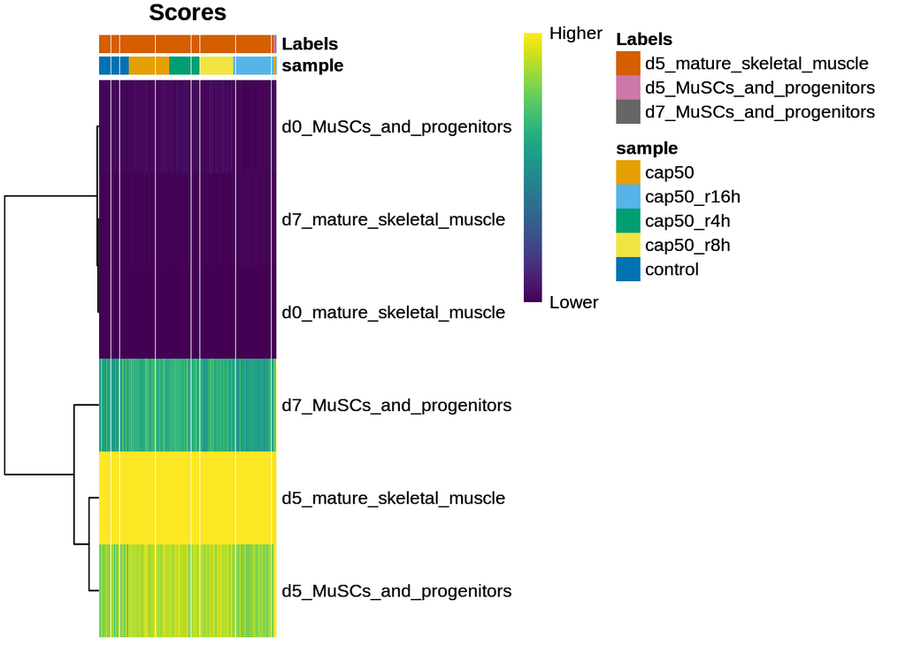

```r
# Score heatmap
plotScoreHeatmap(pred.deMicheli.important.genes, annotation_col = as.data.frame(colData(primary.important.deMicheli)[, "sample", drop = FALSE]), width = 10)
```

```r
# Remove low-quality cells
to.remove <- pruneScores(pred.deMicheli.important.genes, min.diff.next = 0.1)
table(Label=pred.deMicheli.important.genes$labels, Removed=to.remove)
```

```
##                            Removed
## Label                        TRUE
##   d5_mature_skeletal_muscle 21485
##   d5_MuSCs_and_progenitors    305
##   d7_MuSCs_and_progenitors     18
```

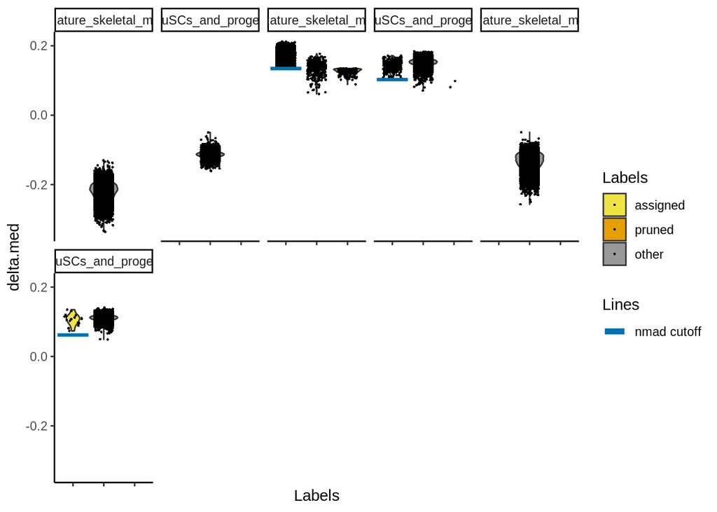

```r
# Delta distribution
plotScoreDistribution(results = pred.deMicheli.important.genes, show = "delta.med")
```

```r
# Markers
all.markers.deMicheli <- metadata(pred.deMicheli.important.genes)$de.genes
primary.important.deMicheli$cell_type_deMicheli <- pred.deMicheli.important.genes$labels
```

**Dell’Orso**

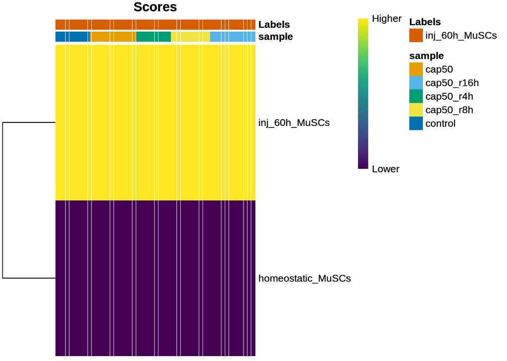

```r
# Score heatmap
plotScoreHeatmap(pred.dellOrso.important.genes, annotation_col = as.data.frame(colData(primary.important.dellOrso)[, "sample", drop = FALSE]), width = 10)
```

```r
# Remove low-quality cells
to.remove <- pruneScores(pred.dellOrso.important.genes, min.diff.next = 0.1)
table(Label=pred.dellOrso.important.genes$labels, Removed=to.remove)
```

```
##                Removed
## Label           FALSE  TRUE
##   inj_60h_MuSCs 21145   663
```

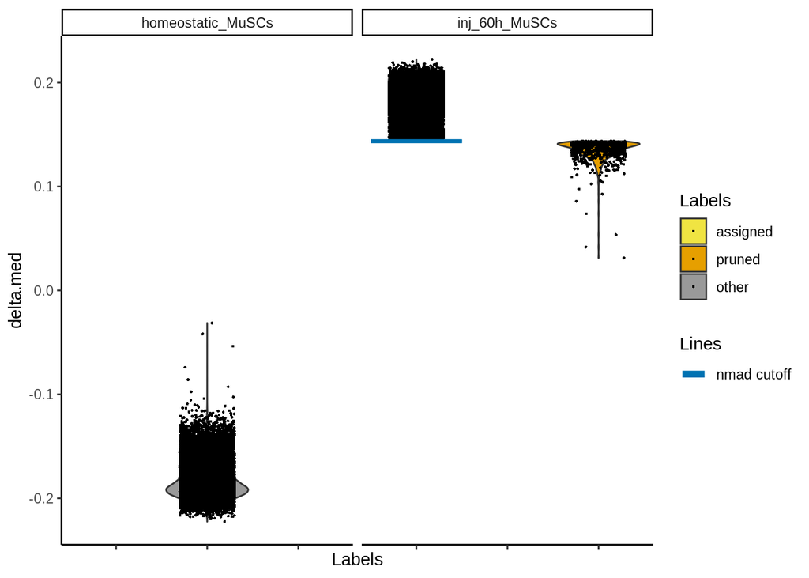

```r
# Delta distribution
plotScoreDistribution(results = pred.dellOrso.important.genes, show = "delta.med")
```

```r
# Markers
all.markers.dellOrso <- metadata(pred.dellOrso.important.genes)$de.genes
primary.important.dellOrso$cell_type_dellOrso <- pred.dellOrso.important.genes$labels
```

**Save PDFs**

```r
#########################
# De Micheli predcitions
#########################
pdf("./../saved/figures/cell_annotation_heatmap_deMicheli_important_genes_d0muscle.pdf")
plotHeatmap(primary.important.deMicheli,
            order_columns_by="cell_type_deMicheli",
            features=unique(unlist(all.markers.deMicheli$d0_mature_skeletal_muscle)),
            fontsize_row = 5)
dev.off()

pdf("./../saved/figures/cell_annotation_heatmap_deMicheli_important_genes_d0musc.pdf")
plotHeatmap(primary.important.deMicheli,
            order_columns_by="cell_type_deMicheli",
            features=unique(unlist(all.markers.deMicheli$d0_MuSCs_and_progenitors)),
            fontsize_row = 5)
dev.off()


pdf("./../saved/figures/cell_annotation_heatmap_deMicheli_important_genes_d5muscle.pdf")
plotHeatmap(primary.important.deMicheli,
            order_columns_by="cell_type_deMicheli",
            features=unique(unlist(all.markers.deMicheli$d5_mature_skeletal_muscle)),
            fontsize_row = 5)
dev.off()


pdf("./../saved/figures/cell_annotation_heatmap_deMicheli_important_genes_d5musc.pdf")
plotHeatmap(primary.important.deMicheli,
            order_columns_by="cell_type_deMicheli",
            features=unique(unlist(all.markers.deMicheli$d5_MuSCs_and_progenitors)),
            fontsize_row = 5)
dev.off()


pdf("./../saved/figures/cell_annotation_heatmap_deMicheli_important_genes_d7muscle.pdf")
plotHeatmap(primary.important.deMicheli,
            order_columns_by="cell_type_deMicheli",
            features=unique(unlist(all.markers.deMicheli$d7_mature_skeletal_muscle)),
            fontsize_row = 5)
dev.off()


pdf("./../saved/figures/cell_annotation_heatmap_deMicheli_important_genes_d7musc.pdf")
plotHeatmap(primary.important.deMicheli,
            order_columns_by="cell_type_deMicheli",
            features=unique(unlist(all.markers.deMicheli$d7_MuSCs_and_progenitors)),
            fontsize_row = 5)
dev.off()

#######################
# Dell'Orso predcitions
#######################
pdf("./../saved/figures/cell_annotation_heatmap_dellOrso_important_genes_hom.pdf")
plotHeatmap(primary.important.dellOrso,
            order_columns_by="cell_type_dellOrso",
            features=unique(unlist(all.markers.dellOrso$homeostatic_MuSCs)),
            fontsize_row = 5)
dev.off()

pdf("./../saved/figures/cell_annotation_heatmap_dellOrso_important_genes_inj60.pdf")
plotHeatmap(primary.important.dellOrso,
            order_columns_by="cell_type_dellOrso",
            features=unique(unlist(all.markers.dellOrso$inj_60h_MuSCs)),
            fontsize_row = 5)
dev.off()

pdf("./../saved/figures/cell_annotation_heatmap_dellOrso_important_genes_pmb.pdf")
plotHeatmap(primary.important.dellOrso,
            order_columns_by="cell_type_dellOrso",
            features=unique(unlist(all.markers.dellOrso$Primary_MB)),
            fontsize_row = 5)
dev.off()
```

### 4.4 Save the DE genes used in SingleR predictions as .csv file

```r
write.csv(de.genes.pred.deMicheli.m, file = "./../saved/tables/de_genes_pred_deMicheli_m.csv")
write.csv(de.genes.pred.deMicheli.m.no.muscle, file = "./../saved/tables/de_genes_pred_deMicheli_m_no_muscle.csv")
write.csv(de.genes.pred.dellOrso.m.no.pm, file = "./../saved/tables/de_genes_pred_dellOrso_m_no_pm.csv")
write.csv(de.genes.pred.deMicheli.important.genes, file = "./../saved/tables/de_genes_pred_deMicheli_important_genes.csv")
write.csv(pred.dellOrso.important.genes, file = "./../saved/tables/de_genes_pred_dellOrso_important_genes.csv")
```

## 5. Differential expression (DE) analysis with metabolic genes

### 5.1 Marker genes: Control vs. Cap samples

**Using t-test**

```r
markers.primary <- findMarkers(denoised.sce.m,
                               groups = denoised.sce.m$sample,
                               lfc = log2(1.5))

# Choose markers for control sample
control.markers <- markers.primary[["control"]]

# Save marker information to .csv file
write.csv(control.markers, file = "./../saved/tables/control_marker_metabolic_genes.csv")

# Subset top 6 genes (ranked by p -value) from each pairwise comparison involving control sample
best.set <- control.markers[control.markers$Top <= 6,]

# Extract the marker effect sizes
logFCs <- getMarkerEffects(best.set)

pheatmap(logFCs, breaks=seq(-5, 5, length.out=101), main = "Metabolic marker genes (t-test): Control vs. other samples (metabolic genes)", fontsize_row = 12)
```

[output not shown]

**Using wmw test**

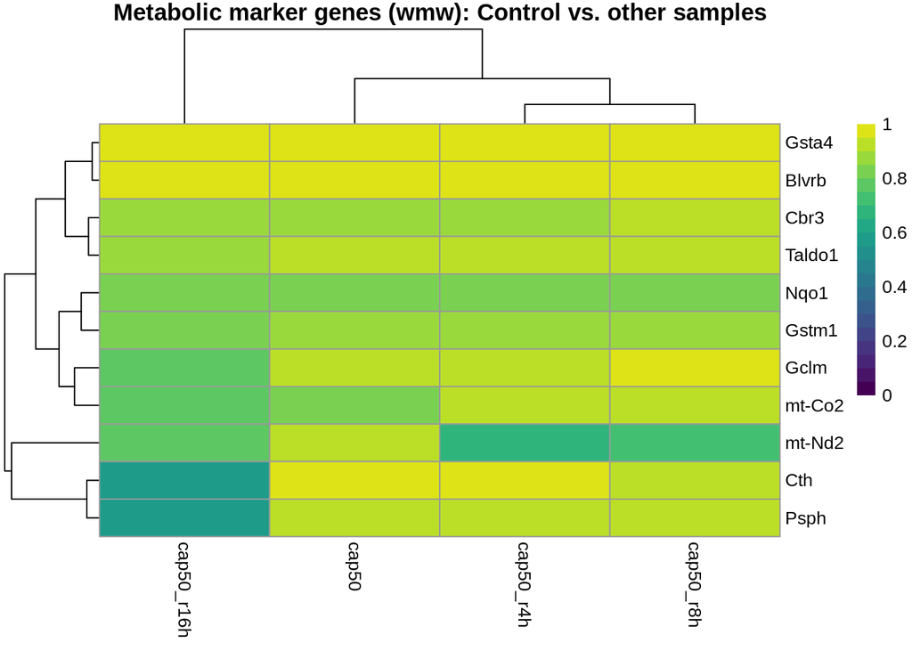

```r
# Find markers by sample
markers.primary.wmw <- findMarkers(denoised.sce.m,
                                   groups = denoised.sce.m$sample,
                                   lfc = log2(1.5),
                                   test = "wilcox")

# Choose markers for control sample
control.markers.wmw <- markers.primary.wmw[["control"]]

# Flip the direction of up / down regulation
control.markers.wmw <- data.frame(as.data.frame(control.markers.wmw)[1:3], apply(control.markers.wmw[4:8], 2, function(x) {abs(1-x)}))

# Save marker information to .csv file
write.csv(control.markers.wmw, file = "./../saved/tables/control_marker_metabolic_genes_wmw.csv")

# Subset top 6 genes (ranked by p -value) from each pairwise comparison involving control sample
best.set <- control.markers.wmw[control.markers.wmw$Top <= 6,]

# Extract the area under curves
AUCs <- getMarkerEffects(best.set, prefix="AUC")

# Plot results in a heatmap
pheatmap(AUCs, breaks=seq(0, 1, length.out=21), color=viridis::viridis(21), main = "Metabolic marker genes (wmw): Control vs. other samples")
```

### 5.2 Marker genes shown on reference trajectories

#### 5.2.1 De Micheli trajectory

```r
# Control marker genes
marker.genes.control <- rownames(best.set)

marker.gene.plots <- list()

# Define de Micheli trajectory space
expression.deMicheli <- as.matrix(t(logcounts(denoised.sce.deMicheli)))
set.seed(123)
space.deMicheli <- reduce_dimensionality(expression.deMicheli, dist = "spearman", ndim = 2)

# Plot trajectory for each marker
for(gene in marker.genes.control) {
  p <- draw_trajectory_plot(space = space.deMicheli,
                            progression_group = expression.deMicheli[, gene],
                            point_size = 1,
                            point_alpha = 0.5,
                            path = traj.deMicheli$path,
                            contour = FALSE) +
  ggtitle(paste(gene, "gene")) +
  theme(plot.title = element_text(size = 14, face = "bold"), axis.title = element_text(size = 10))
  marker.gene.plots[[gene]] <- p
}

gridExtra::grid.arrange(marker.gene.plots$Cth, marker.gene.plots$Taldo1, marker.gene.plots$Gclm, marker.gene.plots$Psph, marker.gene.plots$Gal, marker.gene.plots$Pgd,
                        marker.gene.plots$Cox6a2, marker.gene.plots$Idi1, marker.gene.plots$Sat1, marker.gene.plots$Pck2, marker.gene.plots$Maoa, marker.gene.plots$Gbe1,
                        marker.gene.plots$Eno3, marker.gene.plots$Atp6v1g1, marker.gene.plots$Hgsnat, marker.gene.plots$Atp6v0b, marker.gene.plots$Hexa, marker.gene.plots$Uap1l1,
                        marker.gene.plots$Aldh2, ncol = 4)
```

[output not shown]

#### 5.2.2 Dell’Orso trajectory

```r
# Control marker genes
marker.genes.control <- rownames(best.set)

marker.gene.plots <- list()

# Define de Micheli trajectory space
expression.dellOrso <- as.matrix(t(logcounts(denoised.sce.dellOrso)))
set.seed(123)
space.dellOrso <- reduce_dimensionality(expression.dellOrso, dist = "spearman", ndim = 2)

# Plot trajectory for each marker
for(gene in marker.genes.control) {
  p <- draw_trajectory_plot(space = space.dellOrso,
                            progression_group = expression.dellOrso[, gene],
                            point_size = 1,
                            point_alpha = 0.5,
                            path = traj.dellOrso$path,
                            contour = FALSE) +
  ggtitle(paste(gene, "gene")) +
  theme(plot.title = element_text(size = 14, face = "bold"), axis.title = element_text(size = 10))
  marker.gene.plots[[gene]] <- p
}

gridExtra::grid.arrange(marker.gene.plots$Cth, marker.gene.plots$Taldo1, marker.gene.plots$Gclm, marker.gene.plots$Psph, marker.gene.plots$Gal, marker.gene.plots$Pgd,
                        marker.gene.plots$Cox6a2, marker.gene.plots$Idi1, marker.gene.plots$Sat1, marker.gene.plots$Pck2, marker.gene.plots$Maoa, marker.gene.plots$Gbe1,
                        marker.gene.plots$Eno3, marker.gene.plots$Atp6v1g1, marker.gene.plots$Hgsnat, marker.gene.plots$Atp6v0b, marker.gene.plots$Hexa, marker.gene.plots$Uap1l1,
                        marker.gene.plots$Aldh2, ncol = 4)
```

[output not shown]